# ESTIMACIÓN DE PARAMETROS E INTERVALOS DE CONFIANZA

FUNDAMENTOS, PROCEDIMIENTOS Y APLICACIONES EN EDUCACIÓN

Autor/a

Afiliación

Dayanne Tique Bustamante  
Paula Andrea Saldaña Cuellar  
Jorge Eliecer Riaño Duarte

[Universidad del Tolima](https://www.ut.edu.co/)

Fecha de publicación

12 de noviembre de 2026

[figure not shown]

[figure not shown]

**Ver código**

```r
options(digits = 6)
nivel <- 0.95
alpha <- 1 - nivel
z <- qnorm(1 - alpha/2)
redondear <- function(x, d = 3) round(x, d)
intervalo <- function(estimacion, margen) c(inferior = estimacion-margen, superior = estimacion+margen)
```

# 1 Fundamentos de estimación de parámetros

## 1.1 Estimación puntual

- INTRODUCCIÓN

En estadística inferencial se estudia una **población** mediante una **muestra aleatoria**. Se llama *parámetro* a una característica numérica desconocida de la población, como la media $\mu$, la proporción $p$ o la varianza $\sigma^2$. Un **estadístico** es una función de los datos muestrales. Cuando se usa para aproximar un parámetro recibe el nombre de **estimador** $\widehat\theta$; el número calculado con una muestra concreta es la **estimación**.

$$\widehat\theta=T(X_1,X_2,\ldots,X_n).$$

Por ejemplo, si se desea conocer la nota media de todos los estudiantes de una institución, la media de una muestra aleatoria es una estimación puntual de $\mu$:

$$\overline X=\frac{1}{n}\sum_{i=1}^n X_i.$$

La estimación puntual es sencilla, pero no expresa directamente la incertidumbre muestral. Esa limitación motiva los intervalos de confianza.

- PROPIEDADES DE LOS ESTIMADORES

**A. Insesgadez.** Un estimador es insesgado si su esperanza coincide con el parámetro:

$$\operatorname E(\widehat\theta)=\theta.$$

Para una muestra aleatoria con media $\mu$ y varianza finita $\sigma^2$, se cumple $\operatorname E(\overline X)=\mu$. Para la varianza conviene distinguir:

$$s_n^2=\frac1n\sum_{i=1}^n(X_i-\overline X)^2,\qquad S^2=\frac1{n-1}\sum_{i=1}^n(X_i-\overline X)^2.$$

El primero es sesgado, pues $\operatorname E(s_n^2)=\frac{n-1}{n}\sigma^2$; el segundo es insesgado, pues $\operatorname E(S^2)=\sigma^2$.

**B. Consistencia.** Un estimador es consistente cuando se acerca al parámetro al crecer la muestra:

$$\widehat\theta_n\xrightarrow{P}\theta,\qquad\text{equivalentemente}\quad
\lim_{n\to\infty}P(|\widehat\theta_n-\theta|>\varepsilon)=0\quad(\varepsilon>0).$$

Una condición **suficiente**, aunque no necesaria, es que $\operatorname E(\widehat\theta_n)\to\theta$ y $\operatorname{Var}(\widehat\theta_n)\to0$. En particular, $\operatorname{Var}(\overline X)=\sigma^2/n\to0$.

**C. Eficiencia.** Entre estimadores insesgados de un mismo parámetro, y bajo condiciones comparables, se prefiere el de menor varianza. Para dos estimadores:

$$\operatorname{Var}(\widehat\theta_1)<\operatorname{Var}(\widehat\theta_2)\ \Longrightarrow\ \widehat\theta_1\text{ es más eficiente}.$$

**Importante:** un estimador con varianza menor puede tener más sesgo. Si los estimadores son sesgados, resulta útil comparar el error cuadrático medio $\operatorname{ECM}(\widehat\theta)=\operatorname{Var}(\widehat\theta)+\operatorname{Sesgo}(\widehat\theta)^2$.

- MÉTODOS DE CÁLCULO ESTIMADORES

**A. Método de los momentos.** Se igualan los momentos teóricos de una distribución a los momentos de la muestra y se despejan los parámetros. Si $X$ es Bernoulli$(p)$, $\operatorname E(X)=p$, por lo que:

$$\widehat p_{\mathrm{MM}}=\overline X.$$

**B. Máxima verosimilitud.** Se busca el valor del parámetro que hace más probables los datos observados. Si las observaciones son independientes:

$$L(\theta)=\prod_{i=1}^n f(x_i;\theta),\qquad
\ell(\theta)=\log L(\theta).$$

Para un máximo interior diferenciable se busca una solución de $\ell'(\theta)=0$ y se comprueba que sea un máximo; también hay que considerar los límites del espacio paramétrico. Para una muestra Bernoulli:

$$L(p)=p^{\sum x_i}(1-p)^{n-\sum x_i},$$
$$\ell'(p)=\frac{\sum x_i}{p}-\frac{n-\sum x_i}{1-p}=0
\quad\Longrightarrow\quad \widehat p_{\mathrm{MV}}=\frac{\sum x_i}{n}.$$

Los estimadores de máxima verosimilitud suelen ser consistentes, asintóticamente normales y eficientes **bajo condiciones de regularidad**. La propiedad de invariancia indica que si $\widehat\theta$ maximiza la verosimilitud, $g(\widehat\theta)$ estima por máxima verosimilitud $g(\theta)$, con las condiciones pertinentes.

**Ver código**

```r
# Ejemplo: 18 de 30 estudiantes completan una actividad
respuestas <- c(rep(1, 18), rep(0, 12))
mean(respuestas) # momentos y máxima verosimilitud: p estimada = 0.60
```

```
[1] 0.6
```

## 1.2 Estimación por intervalos de confianza

Un intervalo de confianza (IC) es un procedimiento que produce dos límites a partir de los datos: $[L(X),U(X)]$. Su **nivel de confianza** $1-\alpha$ describe la cobertura del procedimiento en repeticiones del muestreo:

$$P_\theta\big(L(X)\le\theta\le U(X)\big)=1-\alpha.$$

Por ejemplo, el 95 % significa que, si se repite el muestreo muchas veces y se construye el IC del mismo modo, aproximadamente 95 de cada 100 intervalos contendrán el parámetro verdadero. **No** significa que, después de observar la muestra, el parámetro fijo tenga una probabilidad del 95 % de estar dentro de ese intervalo.

Para intervalos simétricos se utiliza:

$$IC=\text{estimación puntual}\ \pm\ \text{valor crítico}\times\text{error estándar}.$$

El **margen de error** $E$ es la semiamplitud: $E=(U-L)/2$. Se emplean las distribuciones normal estándar $Z$, $t$ de Student, ji-cuadrado $\chi^2$ o $F$, según el parámetro y los supuestos. En este material $z_{1-\alpha/2}=\Phi^{-1}(1-\alpha/2)$ y $t_{1-\alpha/2,\nu}$ es el cuantil acumulado correspondiente.

- CASOS PARTICULARES: Mapa de selección

| Parámetro | Situación | Distribución |
| --- | --- | --- |
| Media μ | σ conocida | Normal Z |
| Media μ | σ desconocida | t de Student |
| Proporción p | Aproximación de muestra grande | Normal Z |
| Varianza σ² | Población normal | χ² |
| Diferencia μ₁ − μ₂ | Varianzas conocidas | Normal Z |
| Diferencia μ₁ − μ₂ | Varianzas desconocidas e iguales | t agrupada |
| Diferencia μ₁ − μ₂ | Varianzas desconocidas y distintas | t de Welch |
| Diferencia p₁ − p₂ | Dos muestras independientes grandes | Normal Z |
| Media de diferencias pareadas | Mediciones antes/después | t pareada |

- CONDICIONES Y PRECAUCIONES

La selección aleatoria y la independencia son fundamentales. Para medias, la distribución normal de la población permite inferencia exacta con $t$ (si se desconoce la varianza); con muestras grandes puede utilizarse una aproximación por el teorema central del límite. Para proporciones, los intervalos de tipo Wald presentados en la hoja de fórmulas son aproximados y pueden funcionar mal en muestras pequeñas o proporciones extremas. Para varianzas, la normalidad de la población es especialmente importante. Para datos antes/después, deben analizarse las **diferencias dentro de cada estudiante**, no tratar las dos mediciones como grupos independientes.

- PRECISIÓN Y TAMAÑO DE LA MUESTRA

En general, aumentar el nivel de confianza ensancha el IC; aumentar $n$ disminuye el error estándar. Para estimar una media con desviación poblacional conocida y margen de error máximo $E$:

$$E=z_{1-\alpha/2}\frac{\sigma}{\sqrt n},\qquad
n=\left\lceil\left(\frac{z_{1-\alpha/2}\sigma}{E}\right)^2\right\rceil.$$

Para una proporción, usando un valor de planificación $p_0$:

$$n=\left\lceil\frac{z_{1-\alpha/2}^2p_0(1-p_0)}{E^2}\right\rceil.$$

Si no se conoce $p_0$, elegir $0.5$ produce un tamaño conservador bajo muestreo aleatorio simple. Cuando $\sigma$ es desconocida, el cálculo con $t$ depende de $n$ y puede resolverse iterativamente usando una desviación piloto. Estas expresiones no incorporan corrección por población finita, diseño complejo ni pérdidas por no respuesta.

**Ver código**

```r
# Planeación educativa: precisión de 3 puntos en una prueba,
# sigma estimada previamente en 12 puntos, confianza del 95 %
ceiling((qnorm(0.975)*12/3)^2)
```

```
[1] 62
```

**Ver código**

```r
# Proporción con error de 5 puntos porcentuales
ceiling(qnorm(0.975)^2*0.5*0.5/0.05^2)
```

```
[1] 385
```

# 2 Ejemplos de intervalos de confianza en educación

## 2.1 Ejemplos de intervalos de confianza aplicados a la educación

A continuación, se presentan ocho ejemplos prácticos de intervalos de confianza contextualizados en el ámbito educativo. Cada ejercicio se desarrolla con un nivel de confianza del 95 % e incluye el planteamiento de la situación, la fórmula estadística correspondiente, el procedimiento de cálculo, la interpretación de los resultados y su representación gráfica.

**Para visualizar el desarrollo de cada ejercicio, haga clic sobre el ejemplo de su interés.**

**NotaEjemplo 1. Media con varianza poblacional conocida**

**Situación.** Un distrito educativo desea estimar el puntaje medio de comprensión lectora. Se selecciona una muestra aleatoria de 100 estudiantes. Se supone conocida una desviación estándar poblacional de 12 puntos.

**Fórmula:**

$$IC_{\mu}=\overline{x}\pm z_{1-\alpha/2}
\frac{\sigma}{\sqrt{n}}$$

**Procedimiento y sustitución:**

**Ver código**

```r
set.seed(101)

n <- 100
sigma <- 12
datos <- rnorm(n, 72, sigma)

xbar <- mean(datos)
margen <- z*sigma/sqrt(n)
ic <- intervalo(xbar, margen)

paso(sprintf(
  "\\bar{x}=%.3f,\\quad \\sigma=%.0f,\\quad n=%d",
  xbar, sigma, n
))
```

$$\bar{x}=71.554,\quad \sigma=12,\quad n=100$$

**Ver código**

```r
paso(sprintf(
  "IC_{95\\%%}=%.3f\\pm1.960\\left(\\frac{%.0f}{\\sqrt{%d}}\\right)",
  xbar, sigma, n
))
```

$$IC_{95\%}=71.554\pm1.960\left(\frac{12}{\sqrt{100}}\right)$$

**Ver código**

```r
paso(sprintf(
  "IC_{95\\%%}=%.3f\\pm%.3f",
  xbar, margen
))
```

$$IC_{95\%}=71.554\pm2.352$$

**Ver código**

```r
paso(sprintf(
  "\\boxed{IC_{95\\%%}=[%.3f,\\ %.3f]}",
  ic[1], ic[2]
))
```

$$\boxed{IC_{95\%}=[69.202,\ 73.906]}$$

**Gráfica**

**Ver código**

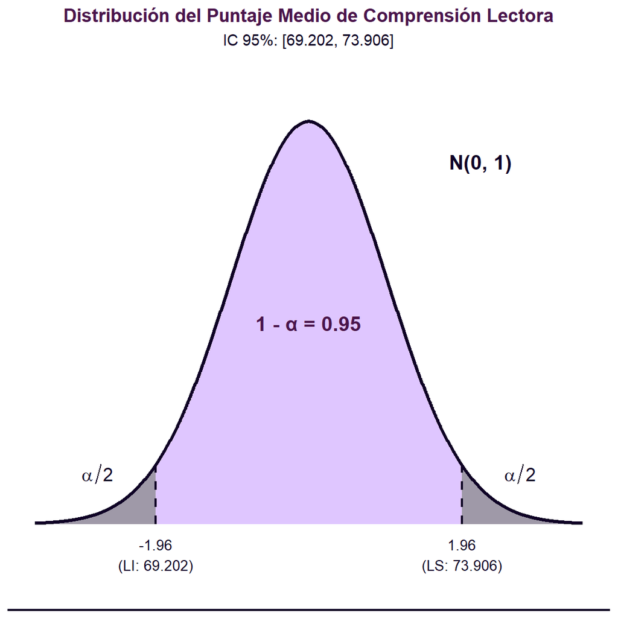

```r
library(ggplot2)

# Parámetros del problema
media_muestral <- 71.554
sigma <- 12
n <- 100
error_estandar <- sigma / sqrt(n)
nivel <- 0.95
alpha <- 1 - nivel
z_critico <- qnorm(1 - alpha/2) # 1.96

# Límites reales del intervalo de confianza
lim_inf <- media_muestral - z_critico * error_estandar # 69.202
lim_sup <- media_muestral + z_critico * error_estandar # 73.906

# Definición de colores
morado <- "#0F0126"
lila <- "#C9A0FF"

# Crear datos para la curva normal estándar N(0,1)
x <- seq(-3.5, 3.5, length.out = 1000)
y <- dnorm(x)
df_curva <- data.frame(x = x, y = y)

# Regiones para el sombreado
df_cola_izq <- data.frame(
  x = c(-3.5, seq(-3.5, -z_critico, length.out = 100), -z_critico),
  y = c(0, dnorm(seq(-3.5, -z_critico, length.out = 100)), 0)
)

df_centro <- data.frame(
  x = c(-z_critico, seq(-z_critico, z_critico, length.out = 200), z_critico),
  y = c(0, dnorm(seq(-z_critico, z_critico, length.out = 200)), 0)
)

df_cola_der <- data.frame(
  x = c(z_critico, seq(z_critico, 3.5, length.out = 100), 3.5),
  y = c(0, dnorm(seq(z_critico, 3.5, length.out = 100)), 0)
)

# Construcción de la gráfica con ggplot2
grafica_contexto <- ggplot(df_curva, aes(x = x, y = y)) +
  # Sombreado de colas en morado
  geom_polygon(data = df_cola_izq, fill = alpha(morado, 0.4)) +
  geom_polygon(data = df_cola_der, fill = alpha(morado, 0.4)) +

  # Sombreado central en lila (nivel de confianza)
  geom_polygon(data = df_centro, fill = alpha(lila, 0.6)) +

  # Línea principal de la campana
  geom_line(color = morado, size = 1.2) +

  # LÍNEAS VERTICALES DIVISORIAS (IMAGINARIAS/PUNTEADAS)
  geom_segment(aes(x = -z_critico, y = 0, xend = -z_critico, yend = dnorm(-z_critico)),
               color = morado, linetype = "dashed", size = 0.8) +
  geom_segment(aes(x = z_critico, y = 0, xend = z_critico, yend = dnorm(z_critico)),
               color = morado, linetype = "dashed", size = 0.8) +

  # Anotaciones de las áreas y datos
  annotate("text", x = 0, y = dnorm(0) / 2, label = paste0("1 - α = ", nivel),
           color = "#4A154B", size = 5, fontface = "bold") +
  annotate("text", x = -2.7, y = 0.05, label = expression(alpha/2), color = morado, size = 4.5) +
  annotate("text", x = 2.7, y = 0.05, label = expression(alpha/2), color = morado, size = 4.5) +

  # Anotación de la distribución
  annotate("text", x = 2.2, y = dnorm(0) * 0.9, label = "N(0, 1)", color = morado, size = 5, fontface = "bold") +

  # Valores en el eje X mostrando tanto Z como los puntajes reales de comprensión lectora
  annotate("text", x = -z_critico, y = -0.03,
           label = paste0("-1.96\n(LI: ", round(lim_inf, 3), ")"),
           color = morado, size = 3.5, hjust = 0.5) +
  annotate("text", x = z_critico, y = -0.03,
           label = paste0("1.96\n(LS: ", round(lim_sup, 3), ")"),
           color = morado, size = 3.5, hjust = 0.5) +

  # Configuración visual
  scale_x_continuous(breaks = NULL, limits = c(-3.5, 3.5)) +
  scale_y_continuous(breaks = NULL, limits = c(-0.06, dnorm(0) * 1.1)) +
  theme_minimal() +
  labs(x = NULL, y = NULL,
       title = "Distribución del Puntaje Medio de Comprensión Lectora",
       subtitle = paste0("IC 95%: [", round(lim_inf, 3), ", ", round(lim_sup, 3), "]")) +
  theme(
    plot.title = element_text(face = "bold", color = "#4A154B", hjust = 0.5, size = 13),
    plot.subtitle = element_text(color = morado, hjust = 0.5, size = 11),
    panel.grid = element_blank(),
    axis.line.x = element_line(color = morado, size = 0.8)
  )

print(grafica_contexto)
```

**Gráfica de 100 intervalos**

**Ver código**

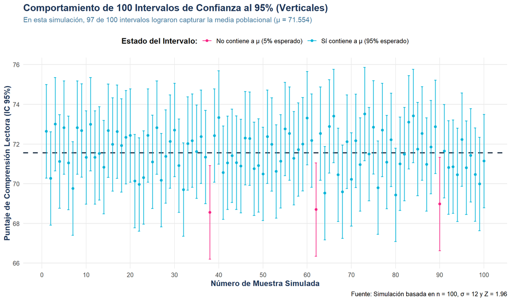

```r
library(dplyr)
library(ggplot2)

# Fijar semilla para reproducibilidad
set.seed(123)

# Parámetros del ejercicio
mu_poblacional <- 71.554
sigma <- 12
n <- 100
z_critico <- qnorm(0.975)
error_estandar <- sigma / sqrt(n)
margen_error <- z_critico * error_estandar
num_simulaciones <- 100

# Simulación de las 100 muestras y cálculo de intervalos
datos_ic <- tibble(
  muestra = 1:num_simulaciones,
  media_muestral = replicate(num_simulaciones, mean(rnorm(n, mean = mu_poblacional, sd = sigma)))
) %>%
  mutate(
    lim_inf = media_muestral - margen_error,
    lim_sup = media_muestral + margen_error,
    contiene_mu = ifelse(lim_inf <= mu_poblacional & lim_sup >= mu_poblacional,
                         "Sí contiene a μ (95% esperado)",
                         "No contiene a μ (5% esperado)")
  )

# Conteo exacto de aciertos
total_aciertos <- sum(datos_ic$lim_inf <= mu_poblacional & datos_ic$lim_sup >= mu_poblacional)

# Creación del gráfico con orientación vertical
ggplot(datos_ic, aes(x = muestra, y = media_muestral, color = contiene_mu)) +
  # Línea horizontal de referencia para la media poblacional real
  geom_hline(yintercept = mu_poblacional, linetype = "dashed", color = "#2C3E50", linewidth = 0.9) +
  # Barras verticales de los intervalos de confianza
  geom_errorbar(aes(ymin = lim_inf, ymax = lim_sup), width = 0.5, linewidth = 0.6, alpha = 0.85) +
  # Puntos centrales (medias muestrales)
  geom_point(size = 1.5) +
  # Paleta de colores distintiva
  scale_color_manual(
    values = c(
      "Sí contiene a μ (95% esperado)" = "#00B4D8",
      "No contiene a μ (5% esperado)" = "#F72585"
    )
  ) +
  scale_x_continuous(breaks = seq(0, 100, by = 10)) +
  labs(
    title = "Comportamiento de 100 Intervalos de Confianza al 95% (Verticales)",
    subtitle = paste0("En esta simulación, ", total_aciertos, " de 100 intervalos lograron capturar la media poblacional (μ = 71.554)"),
    x = "Número de Muestra Simulada",
    y = "Puntaje de Comprensión Lectora (IC 95%)",
    color = "Estado del Intervalo:",
    caption = "Fuente: Simulación basada en n = 100, σ = 12 y Z = 1.96"
  ) +
  theme_minimal(base_size = 12) +
  theme(
    plot.title = element_text(face = "bold", size = 15, color = "#1D3557"),
    plot.subtitle = element_text(size = 11, color = "#457B9D", margin = margin(b = 12)),
    legend.position = "top",
    legend.title = element_text(face = "bold"),
    panel.grid.minor = element_blank(),
    panel.grid.major.x = element_line(color = "#EAEAEA", linewidth = 0.4),
    axis.title = element_text(face = "bold", color = "#1D3557")
  )
```

**Interpretación** Si se construyen 100 intervalos de confianza, se espera que 95 de esos intervalos contengan el verdadero puntaje medio de comprensión lectora de todos los estudiantes del distrito educativo ($\mu = 71.554$ puntos) y 5 no lo contengan.

**NotaEjemplo 2. Media con varianza poblacional desconocida**

**Situación.** Se desea estimar el tiempo medio semanal de estudio autónomo de estudiantes universitarios. Se seleccionan aleatoriamente 25 estudiantes y se supone una población aproximadamente normal.

**Fórmula:**

$$IC_{\mu}=\overline{x}\pm t_{1-\alpha/2,n-1}
\frac{S}{\sqrt{n}}$$

**Procedimiento y sustitución:**

**Ver código**

```r
set.seed(202)

n <- 25
datos <- rnorm(n, 8.4, 2.5)

xbar <- mean(datos)
s <- sd(datos)
gl <- n-1
tcrit <- qt(1-alpha/2, gl)

margen <- tcrit*s/sqrt(n)
ic <- intervalo(xbar, margen)

paso(sprintf(
  "\\bar{x}=%.3f,\\quad S=%.3f,\\quad n=%d",
  xbar, s, n
))
```

$$\bar{x}=8.636,\quad S=2.464,\quad n=25$$

**Ver código**

```r
paso(sprintf(
  "t_{0.975,%d}=%.3f",
  gl, tcrit
))
```

$$t_{0.975,24}=2.064$$

**Ver código**

```r
paso(sprintf(
  "IC_{95\\%%}=%.3f\\pm%.3f\\left(\\frac{%.3f}{\\sqrt{%d}}\\right)",
  xbar, tcrit, s, n
))
```

$$IC_{95\%}=8.636\pm2.064\left(\frac{2.464}{\sqrt{25}}\right)$$

**Ver código**

```r
paso(sprintf(
  "IC_{95\\%%}=%.3f\\pm%.3f",
  xbar, margen
))
```

$$IC_{95\%}=8.636\pm1.017$$

**Ver código**

```r
paso(sprintf(
  "\\boxed{IC_{95\\%%}=[%.3f,\\ %.3f]}",
  ic[1], ic[2]
))
```

$$\boxed{IC_{95\%}=[7.619,\ 9.653]}$$

**Gráfica**

**Ver código**

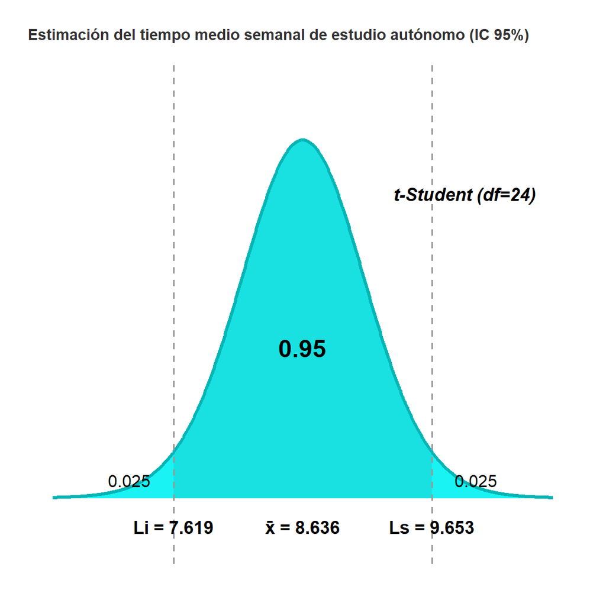

```r
library(ggplot2)

# 1. Datos del ejercicio
x_barra <- 8.636
s <- 2.464
n <- 25
gl <- n - 1                 # Grados de libertad (24)
se <- s / sqrt(n)           # Error estándar (0.4928)
li <- 7.619                 # Límite inferior
ls <- 9.653                 # Límite superior

# 2. Generar la secuencia de puntos para la distribución t escalada
x_vals <- seq(x_barra - 4 * se, x_barra + 4 * se, length.out = 1000)
y_vals <- dt((x_vals - x_barra) / se, df = gl) / se
df_curva <- data.frame(x = x_vals, y = y_vals)

# 3. Subconjuntos para sombrear las diferentes zonas
df_sombra_centro <- subset(df_curva, x >= li & x <= ls)
df_sombra_cola_izq <- subset(df_curva, x <= li)
df_sombra_cola_der <- subset(df_curva, x >= ls)

# 4. Construcción del gráfico en ggplot2 con colas en azul claro
ggplot(df_curva, aes(x = x, y = y)) +
  # Área central (95% en tono original)
  geom_area(data = df_sombra_centro, fill = "#00DEDE", alpha = 0.9) +

  # Áreas de las colas (0.025 en azul bien claro)
  geom_area(data = df_sombra_cola_izq, fill = "#00F2F2", alpha = 0.9) +
  geom_area(data = df_sombra_cola_der, fill = "#00F2F2", alpha = 0.9) +

  # Línea de la curva de densidad
  geom_line(color = "#04B5B5", size = 1.2) +

  # Líneas verticales punteadas en los límites
  geom_vline(xintercept = c(li, ls), linetype = "dashed", color = "gray60", size = 0.7) +

  # Etiquetas de texto dentro y fuera de la curva
  annotate("text", x = x_barra, y = max(y_vals) * 0.42, label = "0.95",
           size = 6, fontface = "bold", color = "black") +
  annotate("text", x = li - 0.35, y = max(y_vals) * 0.05, label = "0.025",
           size = 4.2, color = "black") +
  annotate("text", x = ls + 0.35, y = max(y_vals) * 0.05, label = "0.025",
           size = 4.2, color = "black") +
  annotate("text", x = x_barra + 2.6 * se, y = max(y_vals) * 0.85,
           label = "t-Student (df=24)", size = 4.5, fontface = "bold.italic") +

  # Etiquetas inferiores (Li, Media y Ls)
  annotate("text", x = li, y = -max(y_vals) * 0.08, label = paste0("Li = ", li),
           size = 4.5, fontface = "bold") +
  annotate("text", x = x_barra, y = -max(y_vals) * 0.08, label = paste0("x̄ = ", x_barra),
           size = 4.5, fontface = "bold") +
  annotate("text", x = ls, y = -max(y_vals) * 0.08, label = paste0("Ls = ", ls),
           size = 4.5, fontface = "bold") +

  # Ajustes de escala, título y limpieza visual del lienzo
  coord_cartesian(ylim = c(-max(y_vals) * 0.12, max(y_vals) * 1.15), clip = "off") +
  labs(
    title = "Estimación del tiempo medio semanal de estudio autónomo (IC 95%)"
  ) +
  theme_void() +
  theme(
    plot.background = element_rect(fill = "white", color = NA),
    panel.background = element_rect(fill = "white", color = NA),
    plot.title = element_text(size = 11, face = "bold", color = "#333333", hjust = 0, margin = margin(b = 15)),
    plot.margin = margin(20, 20, 30, 20)
  )
```

**Interpretación.** El intervalo estima, con un nivel de confianza del 95 %, el promedio poblacional de horas semanales dedicadas al estudio autónomo. Se utiliza la distribución t de Student porque la desviación estándar poblacional es desconocida.

**Gráfica de 100 intervalos**

**Ver código**

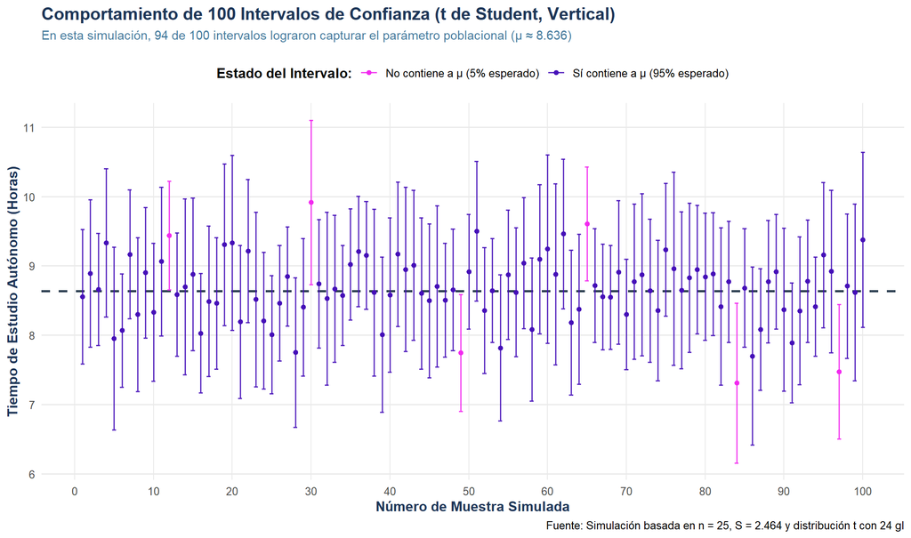

```r
library(dplyr)
library(ggplot2)

# Fijar semilla para reproducibilidad
set.seed(456)

# Parámetros del ejercicio (Varianza desconocida -> t de Student)
media_ref <- 8.636
s_muestral <- 2.464
n <- 25
gl <- n - 1
t_critico <- qt(0.975, df = gl)
num_simulaciones <- 100

# Simulación de las 100 muestras
set.seed(123)
datos_ic <- tibble(
  muestra = 1:num_simulaciones,
  media_muestral_sim = replicate(num_simulaciones, mean(rnorm(n, mean = media_ref, sd = s_muestral))),
  s_sim = replicate(num_simulaciones, sd(rnorm(n, mean = media_ref, sd = s_muestral)))
) %>%
  mutate(
    error_estandar = s_sim / sqrt(n),
    margen_error = t_critico * error_estandar,
    lim_inf = media_muestral_sim - margen_error,
    lim_sup = media_muestral_sim + margen_error,
    contiene_mu = ifelse(lim_inf <= media_ref & lim_sup >= media_ref,
                         "Sí contiene a μ (95% esperado)",
                         "No contiene a μ (5% esperado)")
  )

# Conteo exacto de aciertos
total_aciertos <- sum(datos_ic$lim_inf <= media_ref & datos_ic$lim_sup >= media_ref)

# Creación del gráfico con orientación vertical (muestras en X, intervalos verticales en Y)
ggplot(datos_ic, aes(x = muestra, y = media_muestral_sim, color = contiene_mu)) +
  # Línea horizontal de referencia para la media real de la simulación
  geom_hline(yintercept = media_ref, linetype = "dashed", color = "#2C3E50", linewidth = 0.9) +
  # Barras verticales de los intervalos de confianza
  geom_errorbar(aes(ymin = lim_inf, ymax = lim_sup), width = 0.5, linewidth = 0.6, alpha = 0.85) +
  # Puntos centrales (medias muestrales)
  geom_point(size = 1.5) +
  # Paleta de colores llamativos
  scale_color_manual(
    values = c(
      "Sí contiene a μ (95% esperado)" = "#450FB8",
      "No contiene a μ (5% esperado)" = "#F229EF"
    )
  ) +
  scale_x_continuous(breaks = seq(0, 100, by = 10)) +
  labs(
    title = "Comportamiento de 100 Intervalos de Confianza (t de Student, Vertical)",
    subtitle = paste0("En esta simulación, ", total_aciertos, " de 100 intervalos lograron capturar el parámetro poblacional (μ ≈ 8.636)"),
    x = "Número de Muestra Simulada",
    y = "Tiempo de Estudio Autónomo (Horas)",
    color = "Estado del Intervalo:",
    caption = "Fuente: Simulación basada en n = 25, S = 2.464 y distribución t con 24 gl"
  ) +
  theme_minimal(base_size = 12) +
  theme(
    plot.title = element_text(face = "bold", size = 15, color = "#1D3557"),
    plot.subtitle = element_text(size = 11, color = "#457B9D", margin = margin(b = 12)),
    legend.position = "top",
    legend.title = element_text(face = "bold"),
    panel.grid.minor = element_blank(),
    panel.grid.major.x = element_line(color = "#EAEAEA", linewidth = 0.4),
    axis.title = element_text(face = "bold", color = "#1D3557")
  )
```

**Interpretación** Si se construyen 100 intervalos de confianza, se espera que 95 de esos intervalos van a tener el verdadero tiempo medio de estudio autónomo de los estudiantes universitarios ($\mu \approx 8.636$ horas) y 5 no.

**NotaEjemplo 3. Proporción poblacional**

**Situación.** Una institución educativa desea estimar la proporción de estudiantes que utilizan semanalmente la biblioteca digital. Se encuesta aleatoriamente a 200 estudiantes.

**Fórmula:**

$$\widehat{p}=\frac{x}{n}$$

$$IC_p=\widehat{p}\pm z_{1-\alpha/2}
\sqrt{\frac{\widehat{p}(1-\widehat{p})}{n}}$$

**Procedimiento y sustitución:**

**Ver código**

```r
set.seed(303)

n <- 200
datos <- rbinom(n, 1, 0.75)

exitos <- sum(datos)
phat <- exitos/n

margen <- z*sqrt(phat*(1-phat)/n)
ic <- intervalo(phat, margen)

paso(sprintf(
  "\\widehat{p}=\\frac{%d}{%d}=%.3f",
  exitos, n, phat
))
```

$$\widehat{p}=\frac{147}{200}=0.735$$

**Ver código**

```r
paso(sprintf(
  "IC_{95\\%%}=%.3f\\pm1.960\\sqrt{\\frac{%.3f(1-%.3f)}{%d}}",
  phat, phat, phat, n
))
```

$$IC_{95\%}=0.735\pm1.960\sqrt{\frac{0.735(1-0.735)}{200}}$$

**Ver código**

```r
paso(sprintf(
  "IC_{95\\%%}=%.3f\\pm%.3f",
  phat, margen
))
```

$$IC_{95\%}=0.735\pm0.061$$

**Ver código**

```r
paso(sprintf(
  "\\boxed{IC_{95\\%%}=[%.2f\\%%,\\ %.2f\\%%]}",
  100*ic[1], 100*ic[2]
))
```

$$\boxed{IC_{95\%}=[67.38\%,\ 79.62\%]}$$

**Gráfica**

**Ver código**

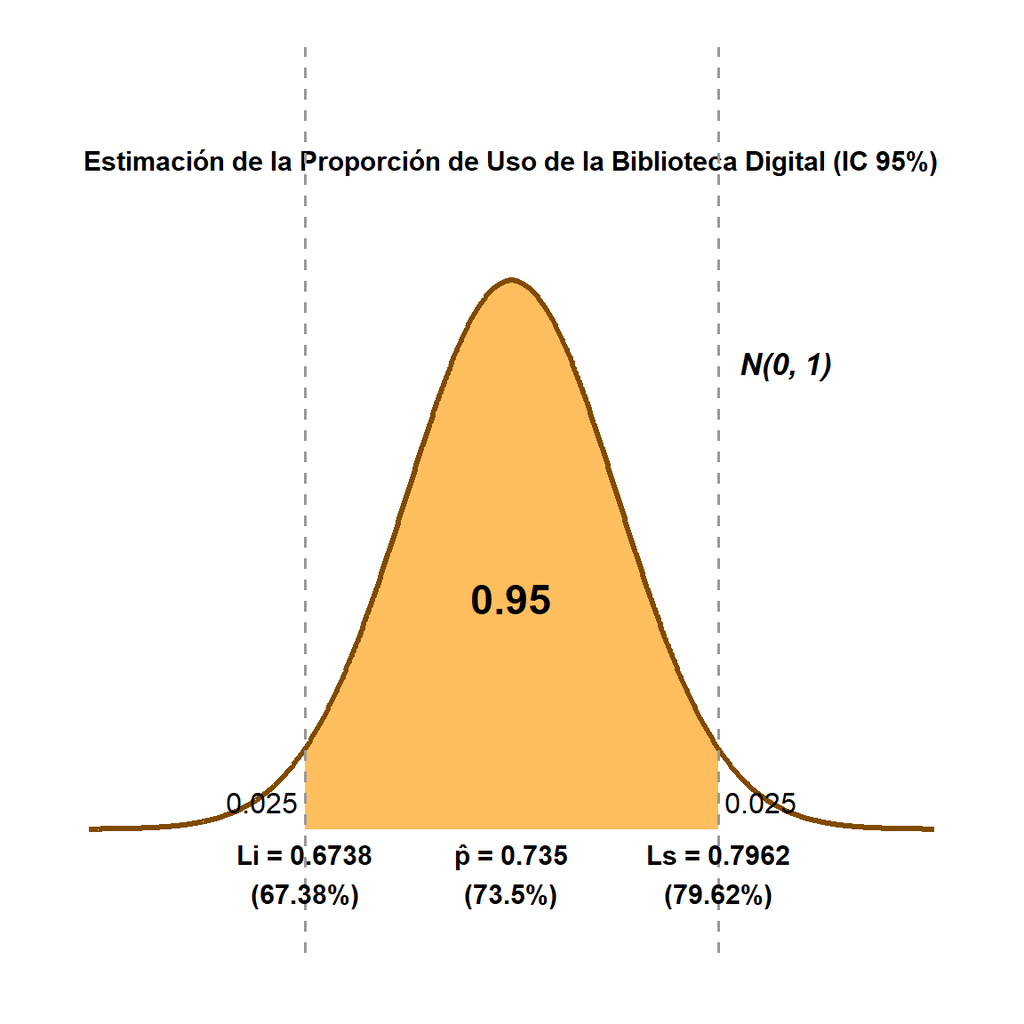

```r
library(ggplot2)

# 1. Datos del ejercicio de proporción
p_hat <- 0.735
n <- 200
se_p <- sqrt((p_hat * (1 - p_hat)) / n)
z_crit <- 1.96
li_p <- 0.6738
ls_p <- 0.7962

# 2. Generar la curva de distribución normal estándar Z
x_vals <- seq(-4, 4, length.out = 1000)
y_vals <- dnorm(x_vals, mean = 0, sd = 1)
df_curva <- data.frame(x = x_vals, y = y_vals)

# 3. Subconjunto para sombrear el área central del 95% (-1.96 a 1.96)
df_sombra <- subset(df_curva, x >= -z_crit & x <= z_crit)

# 4. Construcción del gráfico en ggplot2
ggplot(df_curva, aes(x = x, y = y)) +
  # Título principal pequeño y elegante
  annotate("text", x = 0, y = max(y_vals) * 1.22,
           label = "Estimación de la Proporción de Uso de la Biblioteca Digital (IC 95%)",
           size = 4, fontface = "bold", color = "black", hjust = 0.5) +

  # Área sombreada central (95%)
  geom_area(data = df_sombra, fill = "#FFB74D", alpha = 0.9) +

  # Línea de la curva de densidad
  geom_line(color = "#804B00", size = 1.2) +

  # Líneas verticales punteadas en los límites críticos Z
  geom_vline(xintercept = c(-z_crit, z_crit), linetype = "dashed", color = "gray60", size = 0.7) +

  # Etiquetas de texto dentro y fuera de la curva
  annotate("text", x = 0, y = max(y_vals) * 0.42, label = "0.95",
           size = 6, fontface = "bold", color = "black") +
  annotate("text", x = -z_crit - 0.4, y = max(y_vals) * 0.05, label = "0.025",
           size = 4.2, color = "black") +
  annotate("text", x = z_crit + 0.4, y = max(y_vals) * 0.05, label = "0.025",
           size = 4.2, color = "black") +
  annotate("text", x = 2.6, y = max(y_vals) * 0.85,
           label = "N(0, 1)", size = 4.5, fontface = "bold.italic") +

  # Etiquetas inferiores adaptadas a los valores reales del intervalo
  annotate("text", x = -z_crit, y = -max(y_vals) * 0.08, label = paste0("Li = ", li_p, "\n(67.38%)"),
           size = 4, fontface = "bold") +
  annotate("text", x = 0, y = -max(y_vals) * 0.08, label = paste0("p̂ = ", p_hat, "\n(73.5%)"),
           size = 4, fontface = "bold") +
  annotate("text", x = z_crit, y = -max(y_vals) * 0.08, label = paste0("Ls = ", ls_p, "\n(79.62%)"),
           size = 4, fontface = "bold") +

  # Ajustes de escala y limpieza visual del lienzo
  coord_cartesian(ylim = c(-max(y_vals) * 0.15, max(y_vals) * 1.35), clip = "off") +
  theme_void() +
  theme(
    plot.background = element_rect(fill = "white", color = NA),
    panel.background = element_rect(fill = "white", color = NA),
    plot.margin = margin(20, 20, 30, 20)
  )
```

**Gráfica de 100 intervalos**

**Ver código**

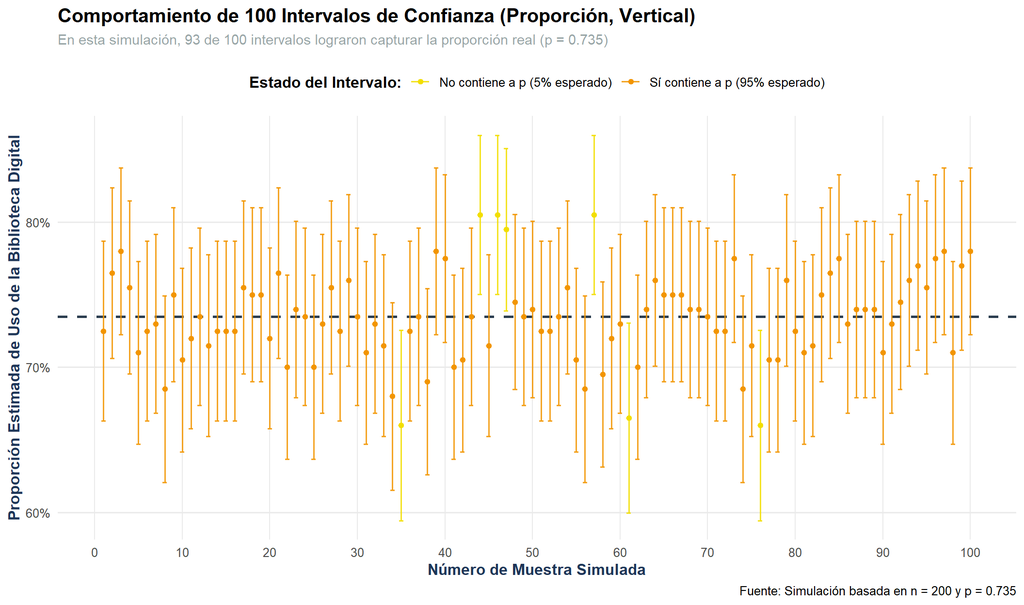

```r
library(dplyr)
library(ggplot2)

# Fijar semilla para reproducibilidad
set.seed(789)

# Parámetros del ejercicio de proporción
p_ref <- 0.735
n <- 200
z_critico <- qnorm(0.975) # 1.959964 (~1.96)
num_simulaciones <- 100

# Simulación de las 100 muestras binomiales / proporciones
datos_ic <- tibble(
  muestra = 1:num_simulaciones,
  x_sim = rbinom(num_simulaciones, size = n, prob = p_ref),
  p_hat_sim = x_sim / n
) %>%
  mutate(
    error_estandar = sqrt((p_hat_sim * (1 - p_hat_sim)) / n),
    margen_error = z_critico * error_estandar,
    lim_inf = p_hat_sim - margen_error,
    lim_sup = p_hat_sim + margen_error,
    contiene_p = ifelse(lim_inf <= p_ref & lim_sup >= p_ref,
                        "Sí contiene a p (95% esperado)",
                        "No contiene a p (5% esperado)")
  )

# Conteo exacto de aciertos
total_aciertos <- sum(datos_ic$lim_inf <= p_ref & datos_ic$lim_sup >= p_ref)

# Creación del gráfico vertical (muestras en X, intervalos verticales en Y)
ggplot(datos_ic, aes(x = muestra, y = p_hat_sim, color = contiene_p)) +
  # Línea horizontal de referencia para la proporción real
  geom_hline(yintercept = p_ref, linetype = "dashed", color = "#2C3E50", linewidth = 0.9) +
  # Barras verticales de los intervalos de confianza
  geom_errorbar(aes(ymin = lim_inf, ymax = lim_sup), width = 0.5, linewidth = 0.6, alpha = 0.85) +
  # Puntos centrales (proporciones muestrales)
  geom_point(size = 1.5) +
  # Paleta de colores llamativos
  scale_color_manual(
    values = c(
      "Sí contiene a p (95% esperado)" = "#F29500",
      "No contiene a p (5% esperado)" = "#F2DE00"
    )
  ) +
  scale_y_continuous(labels = scales::percent_format(accuracy = 1)) +
  scale_x_continuous(breaks = seq(0, 100, by = 10)) +
  labs(
    title = "Comportamiento de 100 Intervalos de Confianza (Proporción, Vertical)",
    subtitle = paste0("En esta simulación, ", total_aciertos, " de 100 intervalos lograron capturar la proporción real (p = 0.735)"),
    x = "Número de Muestra Simulada",
    y = "Proporción Estimada de Uso de la Biblioteca Digital",
    color = "Estado del Intervalo:",
    caption = "Fuente: Simulación basada en n = 200 y p = 0.735"
  ) +
  theme_minimal(base_size = 12) +
  theme(
    plot.title = element_text(face = "bold", size = 15, color = "black"),
    plot.subtitle = element_text(size = 11, color = "#98A5A6", margin = margin(b = 12)),
    legend.position = "top",
    legend.title = element_text(face = "bold"),
    panel.grid.minor = element_blank(),
    panel.grid.major.x = element_line(color = "#EAEAEA", linewidth = 0.4),
    axis.title = element_text(face = "bold", color = "#1D3557")
  )
```

**NotaEjemplo 4. Varianza poblacional**

**Situación.** Se desea estimar la variabilidad de los puntajes de matemáticas de una población estudiantil. Se seleccionan aleatoriamente 20 estudiantes y se supone normalidad poblacional.

**Fórmula:**

$$IC_{\sigma^2}=
\left[
\frac{(n-1)S^2}{\chi^2_{1-\alpha/2,n-1}},
\frac{(n-1)S^2}{\chi^2_{\alpha/2,n-1}}
\right]$$

**Procedimiento y sustitución:**

**Ver código**

```r
set.seed(404)

n <- 20
datos <- rnorm(n, 75, 8)

s2 <- var(datos)
gl <- n-1

chi_inf <- qchisq(alpha/2, gl)
chi_sup <- qchisq(1-alpha/2, gl)

ic <- c(
  inferior = gl*s2/chi_sup,
  superior = gl*s2/chi_inf
)

paso(sprintf(
  "S^2=%.3f,\\quad n=%d,\\quad gl=%d",
  s2, n, gl
))
```

$$S^2=49.215,\quad n=20,\quad gl=19$$

**Ver código**

```r
paso(sprintf(
  "\\chi^2_{0.025,%d}=%.3f,\\quad \\chi^2_{0.975,%d}=%.3f",
  gl, chi_inf, gl, chi_sup
))
```

$$\chi^2_{0.025,19}=8.907,\quad \chi^2_{0.975,19}=32.852$$

**Ver código**

```r
paso(sprintf(
  "IC_{95\\%%}=\\left[\\frac{%d(%.3f)}{%.3f},\\ \\frac{%d(%.3f)}{%.3f}\\right]",
  gl, s2, chi_sup, gl, s2, chi_inf
))
```

$$IC_{95\%}=\left[\frac{19(49.215)}{32.852},\ \frac{19(49.215)}{8.907}\right]$$

**Ver código**

```r
paso(sprintf(
  "\\boxed{IC_{95\\%%}=[%.3f,\\ %.3f]}",
  ic[1], ic[2]
))
```

$$\boxed{IC_{95\%}=[28.463,\ 104.988]}$$

**Ver código**

```r
paso(sprintf(
  "IC_{\\sigma,95\\%%}=[%.3f,\\ %.3f]",
  sqrt(ic[1]), sqrt(ic[2])
))
```

$$IC_{\sigma,95\%}=[5.335,\ 10.246]$$

**Gráfica**

**Ver código**

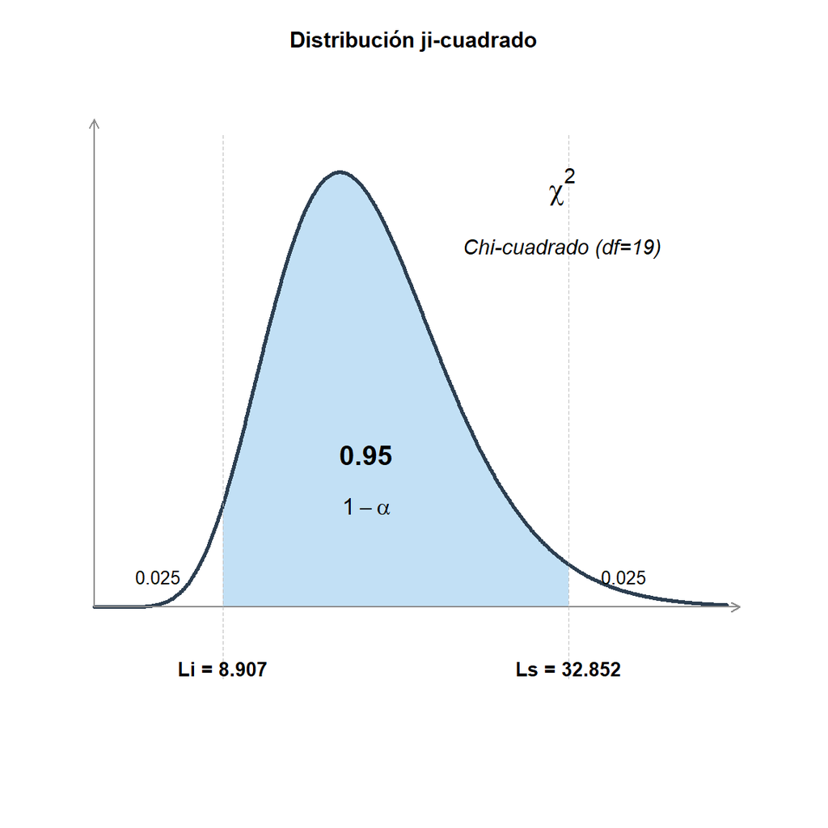

```r
color_linea   <- "#2C3E50" # Color para la curva de densidad y ejes (ej. Azul oscuro / Pizarra)
color_relleno <- "#AED6F1" # Color pastel para el área sombreada central (ej. Azul cielo)
color_lineas_v <- "gray75" # Color para las líneas verticales punteadas
# =====================================================================

# Asegúrate de tener definidas tus variables del ejercicio antes de correr esto:
# gl <- ...
# chi_inf <- ...
# chi_sup <- ...

# 1. Rango y densidad
x_max <- max(qchisq(0.999, gl), chi_sup * 1.15)
x <- seq(0, x_max, length.out = 600)
y <- dchisq(x, gl)
y_max <- max(y) * 1.18

# 2. Lienzo en blanco con espacio arriba para el título pequeño
par(mar = c(3, 1.5, 2.5, 1.5))
plot(x, y, type = "n",
     xlim = c(-x_max * 0.04, x_max * 1.05),
     ylim = c(-y_max * 0.22, y_max),
     axes = FALSE, xlab = "", ylab = "")

# Título principal pequeño en la parte superior
title(main = "Distribución ji-cuadrado", cex.main = 0.95, font.main = 2, line = 0.8)

# 3. Sombreado del área central (1 - alpha)
zona <- x >= chi_inf & x <= chi_sup
polygon(c(chi_inf, x[zona], chi_sup),
        c(0, y[zona], 0),
        col = adjustcolor(color_relleno, alpha.f = 0.75),
        border = NA)

# 4. Curva de densidad encima del sombreado
lines(x, y, col = color_linea, lwd = 2.5)

# 5. Ejes con flechas
arrows(0, 0, x_max * 1.02, 0, length = 0.07, col = "gray55", lwd = 1) # Eje X
arrows(0, 0, 0, y_max * 0.95, length = 0.07, col = "gray55", lwd = 1) # Eje Y

# 6. Líneas verticales sutiles (más delgadas, punteadas y en gris claro)
segments(x0 = c(chi_inf, chi_sup), y0 = -y_max * 0.14,
         x1 = c(chi_inf, chi_sup), y1 = y_max * 0.92,
         col = color_lineas_v, lwd = 0.8, lty = 2)

# 7. Etiquetas de límites inferiores y superiores (Li y Ls)
text(x = chi_inf, y = -y_max * 0.08,
     labels = paste0("Li = ", round(chi_inf, 3)),
     pos = 1, font = 2, cex = 0.85)

text(x = chi_sup, y = -y_max * 0.08,
     labels = paste0("Ls = ", round(chi_sup, 3)),
     pos = 1, font = 2, cex = 0.85)

# 8. Textos interiores centrados en el área sombreada (centroide visual del polígono)
confianza <- round(pchisq(chi_sup, gl) - pchisq(chi_inf, gl), 2)
cola <- round((1 - confianza) / 2, 3)

x_centro <- sum(x[zona] * y[zona]) / sum(y[zona])
y_centro <- mean(y[zona]) * 0.52

text(x = x_centro, y = y_centro + y_max * 0.04,
     labels = confianza, font = 2, cex = 1.2)

text(x = x_centro, y = y_centro - y_max * 0.06,
     labels = expression(1 - alpha), cex = 1)

# 9. Valores de probabilidad en ambas colas (alfa/2)
text(x = chi_inf / 2, y = y_max * 0.06,
     labels = cola, cex = 0.8)

text(x = chi_sup + (x_max - chi_sup) * 0.35, y = y_max * 0.06,
     labels = cola, cex = 0.8)

# 10. Etiqueta flotante de la distribución a la derecha
text(x = x_max * 0.74, y = y_max * 0.82,
     labels = expression(chi^2), cex = 1.3, font = 2)

text(x = x_max * 0.74, y = y_max * 0.70,
     labels = paste0("Chi-cuadrado (df=", gl, ")"),
     font = 3, cex = 0.9)
```

**Interpretación.** El intervalo estima la varianza poblacional de los puntajes, expresada en puntos cuadrados. La raíz cuadrada de sus extremos proporciona un intervalo para la desviación estándar.

La región sombreada representa el 95 % central de la distribución ji-cuadrado utilizada en el procedimiento.

**Gráfica de 100 intervalos**

**Ver código**

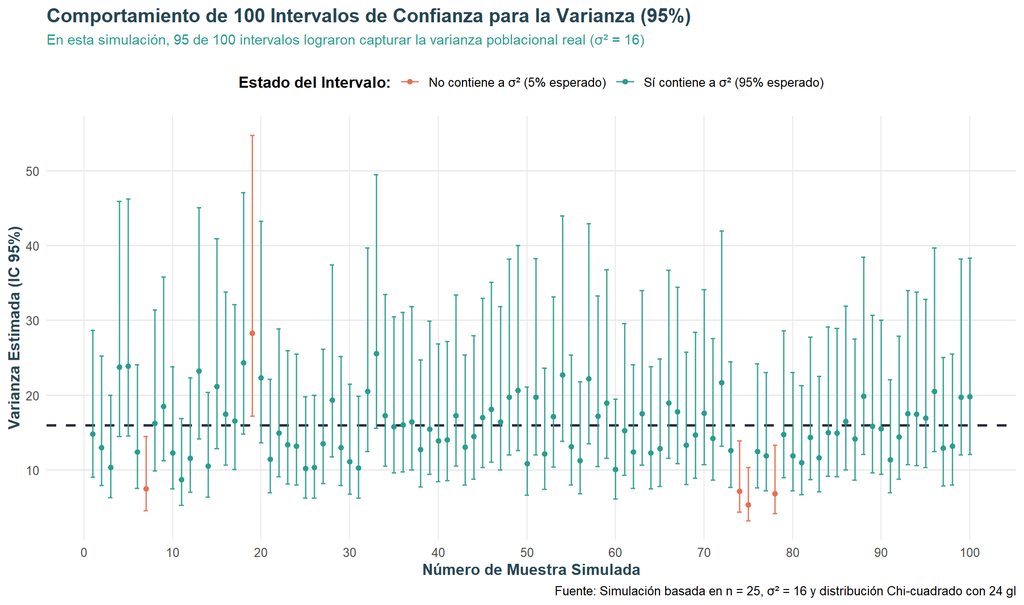

```r
library(dplyr)
library(ggplot2)

# Fijar semilla para reproducibilidad
set.seed(2026)

# Parámetros del ejercicio (ajusta var_ref y n según los datos exactos de tu guía)
var_ref <- 16      # Varianza poblacional de referencia (σ²)
n <- 25            # Tamaño de la muestra
gl <- n - 1        # Grados de libertad (24)
num_simulaciones <- 100

# Valores críticos de Chi-cuadrado al 95% de confianza
chi_sup <- qchisq(0.975, df = gl) # Denominador para el límite inferior
chi_inf <- qchisq(0.025, df = gl) # Denominador para el límite superior

# Simulación de las 100 muestras y cálculo de varianzas muestrales (S²)
datos_ic <- tibble(
  muestra = 1:num_simulaciones,
  s2_sim = replicate(num_simulaciones, var(rnorm(n, mean = 50, sd = sqrt(var_ref))))
) %>%
  mutate(
    lim_inf = (gl * s2_sim) / chi_sup,
    lim_sup = (gl * s2_sim) / chi_inf,
    contiene_var = ifelse(lim_inf <= var_ref & lim_sup >= var_ref,
                          "Sí contiene a σ² (95% esperado)",
                          "No contiene a σ² (5% esperado)")
  )

# Conteo exacto de aciertos
total_aciertos <- sum(datos_ic$lim_inf <= var_ref & datos_ic$lim_sup >= var_ref)

# Creación del gráfico con nueva paleta de colores (Verde Aguamarina vs Naranja Coral)
ggplot(datos_ic, aes(x = muestra, y = s2_sim, color = contiene_var)) +
  # Línea horizontal de referencia para la varianza poblacional real
  geom_hline(yintercept = var_ref, linetype = "dashed", color = "#2B2D42", linewidth = 0.9) +
  # Barras de los intervalos de confianza (asimétricas por la distribución Chi-cuadrado)
  geom_errorbar(aes(ymin = lim_inf, ymax = lim_sup), width = 0.5, linewidth = 0.65, alpha = 0.85) +
  # Puntos centrales (varianzas muestrales S²)
  geom_point(size = 1.6) +
  # Nueva paleta de colores
  scale_color_manual(
    values = c(
      "Sí contiene a σ² (95% esperado)" = "#2A9D8F", # Verde esmeralda / aguamarina
      "No contiene a σ² (5% esperado)" = "#E76F51"  # Naranja coral intenso
    )
  ) +
  scale_x_continuous(breaks = seq(0, 100, by = 10)) +
  labs(
    title = "Comportamiento de 100 Intervalos de Confianza para la Varianza (95%)",
    subtitle = paste0("En esta simulación, ", total_aciertos, " de 100 intervalos lograron capturar la varianza poblacional real (σ² = ", var_ref, ")"),
    x = "Número de Muestra Simulada",
    y = "Varianza Estimada (IC 95%)",
    color = "Estado del Intervalo:",
    caption = paste0("Fuente: Simulación basada en n = ", n, ", σ² = ", var_ref, " y distribución Chi-cuadrado con ", gl, " gl")
  ) +
  theme_minimal(base_size = 12) +
  theme(
    plot.title = element_text(face = "bold", size = 15, color = "#264653"),
    plot.subtitle = element_text(size = 11, color = "#2A9D8F", margin = margin(b = 12)),
    legend.position = "top",
    legend.title = element_text(face = "bold"),
    panel.grid.minor = element_blank(),
    panel.grid.major.x = element_line(color = "#EAEAEA", linewidth = 0.4),
    axis.title = element_text(face = "bold", color = "#264653")
  )
```

**NotaEjemplo 5. Diferencia de medias con varianzas conocidas**

**Situación.** Se comparan los puntajes de matemáticas de dos instituciones independientes. Se consideran conocidas las desviaciones estándar poblacionales: 10 puntos en A y 9 puntos en B.

**Fórmula:**

$$IC_{\mu_1-\mu_2}=
(\overline{x}_1-\overline{x}_2)
\pm z_{1-\alpha/2}
\sqrt{\frac{\sigma_1^2}{n_1}+\frac{\sigma_2^2}{n_2}}$$

**Procedimiento y sustitución:**

**Ver código**

```r
set.seed(505)

n1 <- 64
n2 <- 81
sigma1 <- 10
sigma2 <- 9

A <- rnorm(n1, 78, sigma1)
B <- rnorm(n2, 74, sigma2)

x1 <- mean(A)
x2 <- mean(B)

dif <- x1-x2
margen <- z*sqrt(sigma1^2/n1+sigma2^2/n2)

ic <- intervalo(dif, margen)

paso(sprintf(
  "\\bar{x}_1=%.3f,\\quad \\bar{x}_2=%.3f",
  x1, x2
))
```

$$\bar{x}_1=76.248,\quad \bar{x}_2=74.029$$

**Ver código**

```r
paso(sprintf(
  "\\bar{x}_1-\\bar{x}_2=%.3f-%.3f=%.3f",
  x1, x2, dif
))
```

$$\bar{x}_1-\bar{x}_2=76.248-74.029=2.219$$

**Ver código**

```r
paso(sprintf(
  "IC_{95\\%%}=%.3f\\pm1.960\\sqrt{\\frac{%d}{%d}+\\frac{%d}{%d}}",
  dif, sigma1^2, n1, sigma2^2, n2
))
```

$$IC_{95\%}=2.219\pm1.960\sqrt{\frac{100}{64}+\frac{81}{81}}$$

**Ver código**

```r
paso(sprintf(
  "IC_{95\\%%}=%.3f\\pm%.3f",
  dif, margen
))
```

$$IC_{95\%}=2.219\pm3.137$$

**Ver código**

```r
paso(sprintf(
  "\\boxed{IC_{95\\%%}=[%.3f,\\ %.3f]}",
  ic[1], ic[2]
))
```

$$\boxed{IC_{95\%}=[-0.918,\ 5.357]}$$

**Gráfica**

**Ver código**

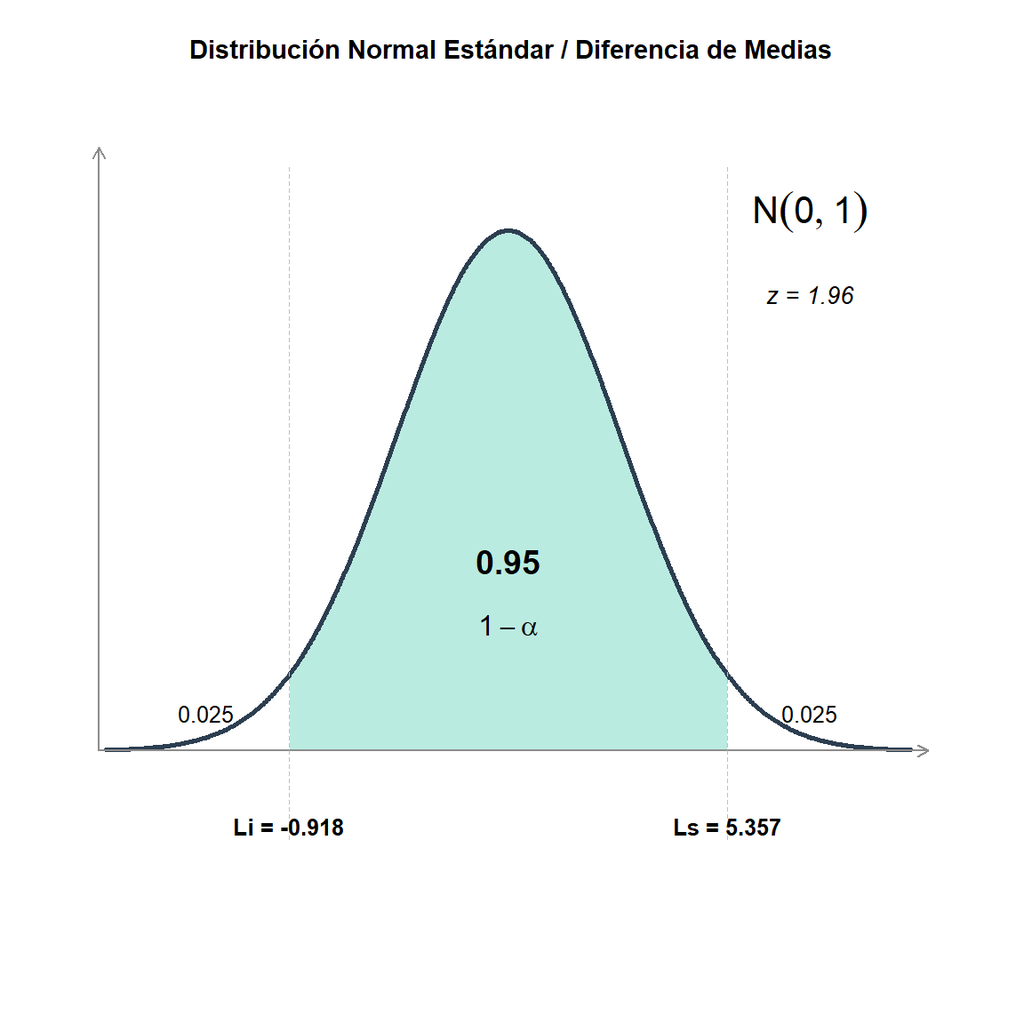

```r
color_linea    <- "#2C3E50" # Azul pizarra oscuro para la curva y ejes
color_relleno  <- "#A3E4D7" # Verde aguamarina pastel para el área central (95%)
color_lineas_v <- "gray75"  # Gris suave para las líneas verticales
# =====================================================================

# 1. Datos del ejercicio (Ejemplo 5: Diferencia de medias)
dif_medias <- 2.219
ee         <- sqrt((100 / 64) + (81 / 81)) # Error estándar = 1.600781
li         <- -0.918
ls         <- 5.357
confianza  <- 0.95
cola       <- 0.025

# 2. Rango y densidad de la campana de Gauss
x_min <- dif_medias - 3.6 * ee
x_max <- dif_medias + 3.6 * ee
x     <- seq(x_min, x_max, length.out = 600)
y     <- dnorm(x, mean = dif_medias, sd = ee)
y_max <- max(y) * 1.22

# 3. Lienzo en blanco con espacio arriba para el título pequeño
par(mar = c(3, 1.5, 2.5, 1.5))
plot(x, y, type = "n",
     xlim = c(x_min - 0.3, x_max + 0.4),
     ylim = c(-y_max * 0.22, y_max),
     axes = FALSE, xlab = "", ylab = "")

# Título principal pequeño en la parte superior
title(main = "Distribución Normal Estándar / Diferencia de Medias",
      cex.main = 0.9, font.main = 2, line = 0.8)

# 4. Sombreado del área central (1 - alpha)
zona <- x >= li & x <= ls
polygon(c(li, x[zona], ls),
        c(0, y[zona], 0),
        col = adjustcolor(color_relleno, alpha.f = 0.75),
        border = NA)

# 5. Curva de Gauss encima del sombreado
lines(x, y, col = color_linea, lwd = 2.5)

# 6. Ejes con flechas (estilo esquema matemático limpio)
arrows(x_min - 0.1, 0, x_max + 0.25, 0, length = 0.07, col = "gray55", lwd = 1) # Eje X
arrows(x_min - 0.1, 0, x_min - 0.1, y_max * 0.95, length = 0.07, col = "gray55", lwd = 1) # Eje Y

# 7. Líneas verticales sutiles en los límites críticos
segments(x0 = c(li, ls), y0 = -y_max * 0.14,
         x1 = c(li, ls), y1 = y_max * 0.92,
         col = color_lineas_v, lwd = 0.8, lty = 2)

# 8. Etiquetas de límites inferiores y superiores con formato -z y z (Li y Ls numéricos)
text(x = li, y = -y_max * 0.08,
     labels = paste0("Li = ", li),
     pos = 1, font = 2, cex = 0.8)

text(x = ls, y = -y_max * 0.08,
     labels = paste0("Ls = ", ls),
     pos = 1, font = 2, cex = 0.8)

# 9. Textos interiores centrados en el área sombreada (igual que la referencia con 1 - alpha)
x_centro <- sum(x[zona] * y[zona]) / sum(y[zona])
y_centro <- mean(y[zona]) * 0.52

text(x = x_centro, y = y_centro + y_max * 0.04,
     labels = confianza, font = 2, cex = 1.15)

text(x = x_centro, y = y_centro - y_max * 0.06,
     labels = expression(1 - alpha), cex = 1)

# 10. Valores de probabilidad en ambas colas (alfa/2)
text(x = li - (li - x_min) * 0.45, y = y_max * 0.06,
     labels = cola, cex = 0.8)

text(x = ls + (x_max - ls) * 0.45, y = y_max * 0.06,
     labels = cola, cex = 0.8)

# 11. Etiqueta flotante de la distribución a la derecha (estilo N(0,1) de tu referencia)
text(x = x_max * 0.82, y = y_max * 0.85,
     labels = expression(N(0, 1)), cex = 1.3, font = 2)

text(x = x_max * 0.82, y = y_max * 0.72,
     labels = "z = 1.96",
     font = 3, cex = 0.85)
```

**Interpretación.** El intervalo del 95 % estima la diferencia entre las medias poblacionales de las dos instituciones. Si contiene cero, no se descarta una diferencia nula al nivel bilateral del 5 %. Si no lo contiene, existe evidencia estadística de una diferencia.

**Gráfica de 100 intervalos**

**Ver código**

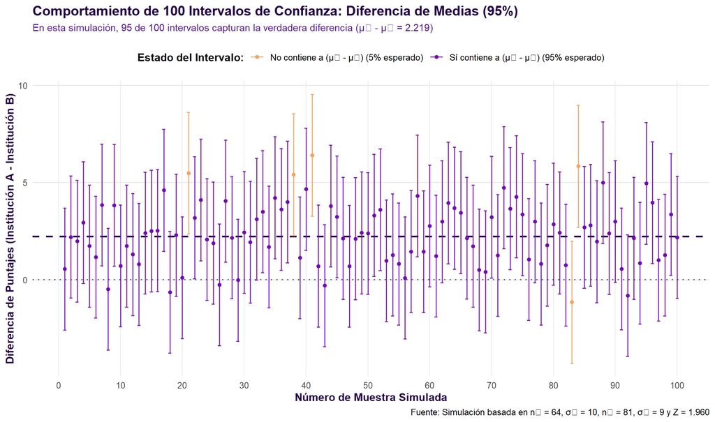

```r
library(dplyr)
library(ggplot2)

# Fijar semilla para reproducibilidad
set.seed(101)

# Parámetros exactos del ejercicio
mu1_ref <- 76.248
sigma1 <- 10
n1 <- 64

mu2_ref <- 74.029
sigma2 <- 9
n2 <- 81

diff_real <- mu1_ref - mu2_ref # 2.219
z_critico <- qnorm(0.975)      # 1.959964 (~1.960)
error_estandar <- sqrt((sigma1^2 / n1) + (sigma2^2 / n2)) # ~1.60078
margen_error <- z_critico * error_estandar # ~3.137
num_simulaciones <- 100

# Simulación de las 100 pares de muestras independientes
datos_ic <- tibble(
  muestra = 1:num_simulaciones,
  x1_sim = replicate(num_simulaciones, mean(rnorm(n1, mean = mu1_ref, sd = sigma1))),
  x2_sim = replicate(num_simulaciones, mean(rnorm(n2, mean = mu2_ref, sd = sigma2)))
) %>%
  mutate(
    diff_muestral = x1_sim - x2_sim,
    lim_inf = diff_muestral - margen_error,
    lim_sup = diff_muestral + margen_error,
    contiene_diff = ifelse(lim_inf <= diff_real & lim_sup >= diff_real,
                           "Sí contiene a (μ₁ - μ₂) (95% esperado)",
                           "No contiene a (μ₁ - μ₂) (5% esperado)")
  )

# Conteo exacto de aciertos
total_aciertos <- sum(datos_ic$lim_inf <= diff_real & datos_ic$lim_sup >= diff_real)

# Creación del gráfico con nueva paleta de colores (Violeta Intenso vs Ámbar/Dorado)
ggplot(datos_ic, aes(x = muestra, y = diff_muestral, color = contiene_diff)) +
  # Línea de referencia en 0 (indica igualdad de medias)
  geom_hline(yintercept = 0, linetype = "dotted", color = "#6C757D", linewidth = 0.8) +
  # Línea horizontal de referencia para la diferencia poblacional real (2.219)
  geom_hline(yintercept = diff_real, linetype = "dashed", color = "#240046", linewidth = 0.9) +
  # Barras de los intervalos de confianza
  geom_errorbar(aes(ymin = lim_inf, ymax = lim_sup), width = 0.5, linewidth = 0.65, alpha = 0.85) +
  # Puntos centrales (diferencias muestrales)
  geom_point(size = 1.6) +
  # Paleta de colores renovada
  scale_color_manual(
    values = c(
      "Sí contiene a (μ₁ - μ₂) (95% esperado)" = "#7209B7", # Morado / Violeta vibrante
      "No contiene a (μ₁ - μ₂) (5% esperado)" = "#F4A261"  # Ámbar / Naranja dorado
    )
  ) +
  scale_x_continuous(breaks = seq(0, 100, by = 10)) +
  labs(
    title = "Comportamiento de 100 Intervalos de Confianza: Diferencia de Medias (95%)",
    subtitle = paste0("En esta simulación, ", total_aciertos, " de 100 intervalos capturan la verdadera diferencia (μ₁ - μ₂ = 2.219)"),
    x = "Número de Muestra Simulada",
    y = "Diferencia de Puntajes (Institución A - Institución B)",
    color = "Estado del Intervalo:",
    caption = "Fuente: Simulación basada en n₁ = 64, σ₁ = 10, n₂ = 81, σ₂ = 9 y Z = 1.960"
  ) +
  theme_minimal(base_size = 12) +
  theme(
    plot.title = element_text(face = "bold", size = 15, color = "#240046"),
    plot.subtitle = element_text(size = 11, color = "#5A189A", margin = margin(b = 12)),
    legend.position = "top",
    legend.title = element_text(face = "bold"),
    panel.grid.minor = element_blank(),
    panel.grid.major.x = element_line(color = "#EAEAEA", linewidth = 0.4),
    axis.title = element_text(face = "bold", color = "#240046")
  )
```

**Interpretación** Si se construyen 100 intervalos de confianza, se espera que 95 de esos intervalos van a tener la verdadera diferencia de medias entre los puntajes de matemáticas de las dos instituciones ($\mu_1 - \mu_2 = 2.219$ puntos) y 5 no.

**NotaEjemplo 6. Diferencia de medias con varianzas desconocidas e iguales**

**Situación.** Se comparan dos metodologías de enseñanza aplicadas a grupos independientes. Se supone que las varianzas poblacionales son iguales, aunque desconocidas.

**Fórmulas:**

$$S_p^2=
\frac{(n_1-1)S_1^2+(n_2-1)S_2^2}
{n_1+n_2-2}$$

$$IC_{\mu_1-\mu_2}=
(\overline{x}_1-\overline{x}_2)
\pm t_{1-\alpha/2,n_1+n_2-2}
S_p\sqrt{\frac1{n_1}+\frac1{n_2}}$$

**Procedimiento y sustitución:**

**Ver código**

```r
set.seed(606)

n1 <- 30
n2 <- 28

A <- rnorm(n1, 82, 8)
B <- rnorm(n2, 77, 8)

x1 <- mean(A)
x2 <- mean(B)
s1 <- sd(A)
s2 <- sd(B)

gl <- n1+n2-2

sp2 <- ((n1-1)*s1^2+(n2-1)*s2^2)/gl
sp <- sqrt(sp2)

tcrit <- qt(1-alpha/2, gl)
dif <- x1-x2

margen <- tcrit*sp*sqrt(1/n1+1/n2)
ic <- intervalo(dif, margen)

paso(sprintf(
  "\\bar{x}_1=%.3f,\\quad \\bar{x}_2=%.3f",
  x1, x2
))
```

$$\bar{x}_1=82.823,\quad \bar{x}_2=74.457$$

**Ver código**

```r
paso(sprintf(
  "S_p^2=\\frac{%d(%.3f)^2+%d(%.3f)^2}{%d}=%.3f",
  n1-1, s1, n2-1, s2, gl, sp2
))
```

$$S_p^2=\frac{29(8.523)^2+27(8.579)^2}{56}=73.104$$

**Ver código**

```r
paso(sprintf(
  "IC_{95\\%%}=%.3f\\pm%.3f(%.3f)\\sqrt{\\frac1{%d}+\\frac1{%d}}",
  dif, tcrit, sp, n1, n2
))
```

$$IC_{95\%}=8.367\pm2.003(8.550)\sqrt{\frac1{30}+\frac1{28}}$$

**Ver código**

```r
paso(sprintf(
  "IC_{95\\%%}=%.3f\\pm%.3f",
  dif, margen
))
```

$$IC_{95\%}=8.367\pm4.501$$

**Ver código**

```r
paso(sprintf(
  "\\boxed{IC_{95\\%%}=[%.3f,\\ %.3f]}",
  ic[1], ic[2]
))
```

$$\boxed{IC_{95\%}=[3.866,\ 12.867]}$$

**Gráfica**

**Ver código**

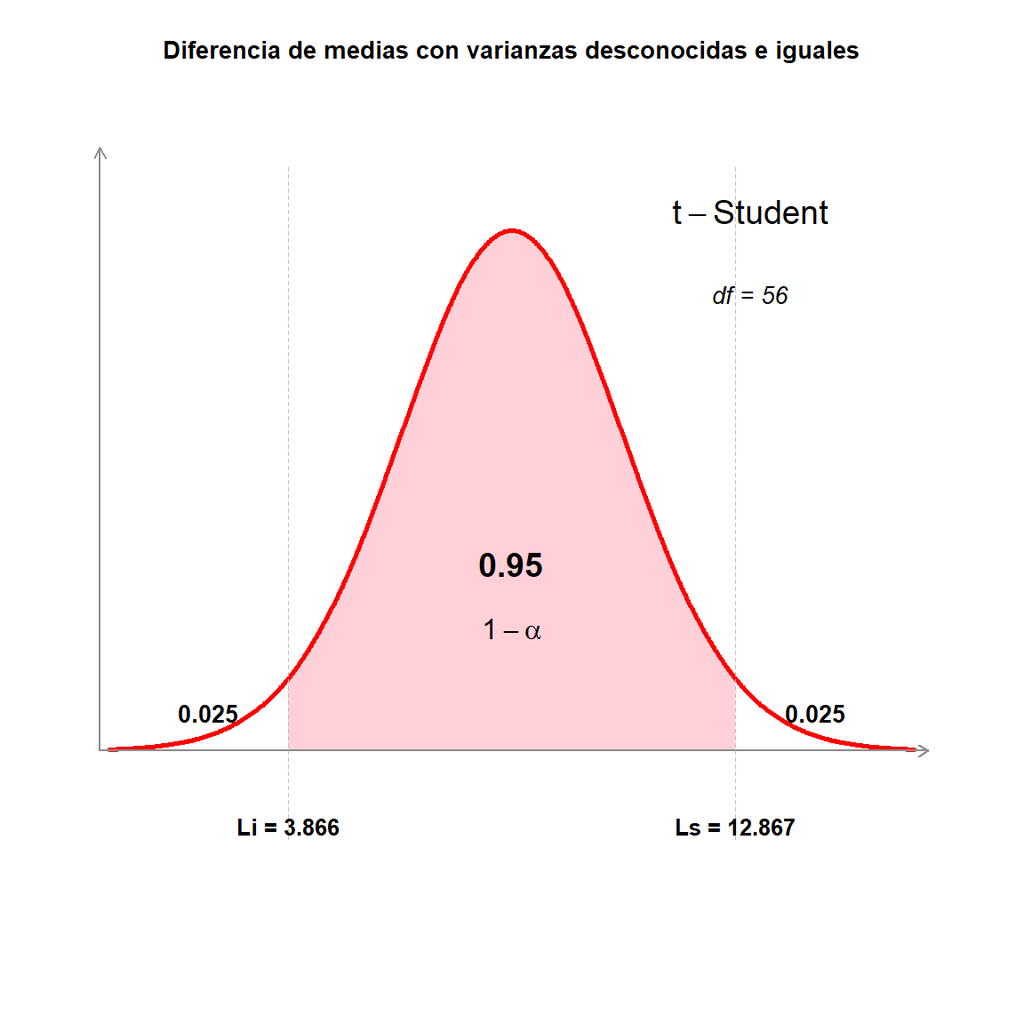

```r
color_linea     <- "red" # Azul pizarra oscuro para la curva y ejes
color_relleno   <- "pink" # Verde aguamarina pastel para el área central (95%)
color_lineas_v  <- "gray75"  # Gris suave para las líneas verticales
color_rosado    <- "black" # Rosado pastel para los valores de las colas y títulos
# =====================================================================

# 1. Datos del ejercicio (Diferencia de medias - t-Student)
dif_medias <- 8.367
gl         <- 56
li         <- 3.866
ls         <- 12.867
confianza  <- 0.95
cola       <- 0.025

# 2. Rango y densidad de la distribución t-Student escalada a los datos
ee         <- 4.501 / 2.003 # Error estándar
x_min      <- dif_medias - 3.6 * ee
x_max      <- dif_medias + 3.6 * ee
x          <- seq(x_min, x_max, length.out = 600)
y          <- dt((x - dif_medias) / ee, df = gl) / ee
y_max      <- max(y) * 1.22

# 3. Lienzo en blanco con espacio arriba para el título pequeño
par(mar = c(3, 1.5, 2.5, 1.5))
plot(x, y, type = "n",
     xlim = c(x_min - 0.5, x_max + 0.5),
     ylim = c(-y_max * 0.22, y_max),
     axes = FALSE, xlab = "", ylab = "")

# Título principal corregido del ejercicio en la parte superior
title(main = "Diferencia de medias con varianzas desconocidas e iguales",
      cex.main = 0.85, font.main = 2, line = 0.8)

# 4. Sombreado del área central (1 - alpha)
zona <- x >= li & x <= ls
polygon(c(li, x[zona], ls),
        c(0, y[zona], 0),
        col = adjustcolor(color_relleno, alpha.f = 0.75),
        border = NA)

# 5. Curva t-Student encima del sombreado
lines(x, y, col = color_linea, lwd = 2.5)

# 6. Ejes con flechas
arrows(x_min - 0.2, 0, x_max + 0.3, 0, length = 0.07, col = "gray55", lwd = 1) # Eje X
arrows(x_min - 0.2, 0, x_min - 0.2, y_max * 0.95, length = 0.07, col = "gray55", lwd = 1) # Eje Y

# 7. Líneas verticales sutiles en los límites críticos
segments(x0 = c(li, ls), y0 = -y_max * 0.14,
         x1 = c(li, ls), y1 = y_max * 0.92,
         col = color_lineas_v, lwd = 0.8, lty = 2)

# 8. Etiquetas de límites inferiores y superiores (Li y Ls numéricos)
text(x = li, y = -y_max * 0.08,
     labels = paste0("Li = ", li),
     pos = 1, font = 2, cex = 0.8)

text(x = ls, y = -y_max * 0.08,
     labels = paste0("Ls = ", ls),
     pos = 1, font = 2, cex = 0.8)

# 9. Textos interiores centrados en el área sombreada (1 - alpha)
x_centro <- sum(x[zona] * y[zona]) / sum(y[zona])
y_centro <- mean(y[zona]) * 0.52

text(x = x_centro, y = y_centro + y_max * 0.04,
     labels = confianza, font = 2, cex = 1.15)

text(x = x_centro, y = y_centro - y_max * 0.06,
     labels = expression(1 - alpha), cex = 1)

# 10. Valores de probabilidad en ambas colas (en rosado pastel)
text(x = li - (li - x_min) * 0.45, y = y_max * 0.06,
     labels = cola, cex = 0.85, font = 2, col = color_rosado)

text(x = ls + (x_max - ls) * 0.45, y = y_max * 0.06,
     labels = cola, cex = 0.85, font = 2, col = color_rosado)

# 11. Etiqueta flotante de la t-Student a la derecha (en rosado pastel)
text(x = x_max * 0.80, y = y_max * 0.85,
     labels = expression(t-Student), cex = 1.2, font = 2, col = color_rosado)

text(x = x_max * 0.80, y = y_max * 0.72,
     labels = paste0("df = ", gl),
     font = 3, cex = 0.85, col = color_rosado)
```

**Interpretación.** El intervalo del 95 % estima la diferencia entre los promedios poblacionales de ambas metodologías. Se utiliza una varianza agrupada bajo el supuesto de igualdad de varianzas poblacionales.

**Gráfica de 100 intervalos**

**Ver código**

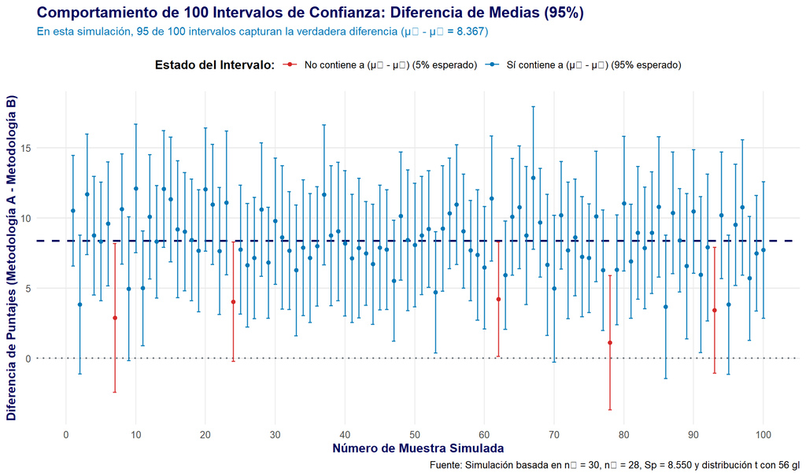

```r
library(dplyr)
library(ggplot2)

# Fijar semilla para reproducibilidad
set.seed(303)

# Parámetros exactos del ejercicio
mu1_ref <- 82.823
s1_ref <- 8.523
n1 <- 30

mu2_ref <- 74.457
s2_ref <- 8.579
n2 <- 28

sp_ref <- 8.550 # Desviación estándar agrupada de referencia
diff_real <- mu1_ref - mu2_ref # 8.366 (~8.367 en el ejercicio)
gl <- n1 + n2 - 2 # 56 grados de libertad
t_critico <- qt(0.975, df = gl) # 2.003241 (~2.003)
num_simulaciones <- 100

# Simulación de las 100 pares de muestras independientes
datos_ic <- tibble(
  muestra = 1:num_simulaciones
) %>%
  rowwise() %>%
  mutate(
    # Generar muestras normales con la desviación estándar agrupada como parámetro común
    m1 = list(rnorm(n1, mean = mu1_ref, sd = sp_ref)),
    m2 = list(rnorm(n2, mean = mu2_ref, sd = sp_ref)),
    x1_sim = mean(m1),
    x2_sim = mean(m2),
    s1_sim = sd(m1),
    s2_sim = sd(m2),
    diff_muestral = x1_sim - x2_sim,
    # Cálculo de la varianza agrupada (Sp^2) y desviación agrupada (Sp) por muestra
    sp2_sim = ((n1 - 1) * s1_sim^2 + (n2 - 1) * s2_sim^2) / gl,
    sp_sim = sqrt(sp2_sim),
    error_estandar = sp_sim * sqrt((1 / n1) + (1 / n2)),
    margen_error = t_critico * error_estandar,
    lim_inf = diff_muestral - margen_error,
    lim_sup = diff_muestral + margen_error,
    contiene_diff = ifelse(lim_inf <= diff_real & lim_sup >= diff_real,
                           "Sí contiene a (μ₁ - μ₂) (95% esperado)",
                           "No contiene a (μ₁ - μ₂) (5% esperado)")
  ) %>%
  ungroup()

# Conteo exacto de aciertos
total_aciertos <- sum(datos_ic$lim_inf <= diff_real & datos_ic$lim_sup >= diff_real)

# Creación del gráfico con nueva paleta de colores (Azul Cobalto vs Rojo Carmesí)
ggplot(datos_ic, aes(x = muestra, y = diff_muestral, color = contiene_diff)) +
  # Línea de referencia en 0 (indica igualdad entre metodologías)
  geom_hline(yintercept = 0, linetype = "dotted", color = "#6C757D", linewidth = 0.8) +
  # Línea horizontal de referencia para la diferencia poblacional real (8.367)
  geom_hline(yintercept = diff_real, linetype = "dashed", color = "#03045E", linewidth = 0.9) +
  # Barras de los intervalos de confianza
  geom_errorbar(aes(ymin = lim_inf, ymax = lim_sup), width = 0.5, linewidth = 0.65, alpha = 0.85) +
  # Puntos centrales (diferencias muestrales)
  geom_point(size = 1.6) +
  # Nueva paleta de colores
  scale_color_manual(
    values = c(
      "Sí contiene a (μ₁ - μ₂) (95% esperado)" = "#0077B6", # Azul cobalto / océano
      "No contiene a (μ₁ - μ₂) (5% esperado)" = "#D62828"  # Rojo carmesí vibrante
    )
  ) +
  scale_x_continuous(breaks = seq(0, 100, by = 10)) +
  labs(
    title = "Comportamiento de 100 Intervalos de Confianza: Diferencia de Medias (95%)",
    subtitle = paste0("En esta simulación, ", total_aciertos, " de 100 intervalos capturan la verdadera diferencia (μ₁ - μ₂ = 8.367)"),
    x = "Número de Muestra Simulada",
    y = "Diferencia de Puntajes (Metodología A - Metodología B)",
    color = "Estado del Intervalo:",
    caption = "Fuente: Simulación basada en n₁ = 30, n₂ = 28, Sp = 8.550 y distribución t con 56 gl"
  ) +
  theme_minimal(base_size = 12) +
  theme(
    plot.title = element_text(face = "bold", size = 15, color = "#03045E"),
    plot.subtitle = element_text(size = 11, color = "#0077B6", margin = margin(b = 12)),
    legend.position = "top",
    legend.title = element_text(face = "bold"),
    panel.grid.minor = element_blank(),
    panel.grid.major.x = element_line(color = "#EAEAEA", linewidth = 0.4),
    axis.title = element_text(face = "bold", color = "#03045E")
  )
```

**Interpretación** Si se construyen 100 intervalos de confianza, se espera que 95 de esos intervalos van a tener la verdadera diferencia de medias entre los puntajes de las dos metodologías de enseñanza ($\mu_1 - \mu_2 = 8.367$ puntos) y 5 no.

**NotaEjemplo 7. Diferencia de medias con varianzas distintas (Welch)**

**Situación.** Se compara el rendimiento en resolución de problemas de dos colegios independientes. Las varianzas poblacionales son desconocidas y no se supone que sean iguales.

**Fórmulas:**

$$IC_{\mu_1-\mu_2}=
(\overline{x}_1-\overline{x}_2)
\pm t_{1-\alpha/2,\nu}
\sqrt{\frac{S_1^2}{n_1}+\frac{S_2^2}{n_2}}$$

$$\nu\approx
\frac{(S_1^2/n_1+S_2^2/n_2)^2}
{\dfrac{(S_1^2/n_1)^2}{n_1-1}
+\dfrac{(S_2^2/n_2)^2}{n_2-1}}$$

**Procedimiento y sustitución:**

**Ver código**

```r
set.seed(707)

n1 <- 25
n2 <- 35

A <- rnorm(n1, 85, 12)
B <- rnorm(n2, 79, 7)

x1 <- mean(A)
x2 <- mean(B)

s1 <- sd(A)
s2 <- sd(B)

a <- s1^2/n1
b <- s2^2/n2

nu <- (a+b)^2/(a^2/(n1-1)+b^2/(n2-1))

tcrit <- qt(1-alpha/2, nu)

dif <- x1-x2
margen <- tcrit*sqrt(a+b)

ic <- intervalo(dif, margen)

paso(sprintf(
  "\\bar{x}_1=%.3f,\\quad \\bar{x}_2=%.3f",
  x1, x2
))
```

$$\bar{x}_1=86.212,\quad \bar{x}_2=79.674$$

**Ver código**

```r
paso(sprintf(
  "\\nu=\\frac{(%.3f+%.3f)^2}{\\frac{(%.3f)^2}{%d}+\\frac{(%.3f)^2}{%d}}=%.3f",
  a, b, a, n1-1, b, n2-1, nu
))
```

$$\nu=\frac{(5.750+1.152)^2}{\frac{(5.750)^2}{24}+\frac{(1.152)^2}{34}}=33.624$$

**Ver código**

```r
paso(sprintf(
  "IC_{95\\%%}=%.3f\\pm%.3f\\sqrt{\\frac{(%.3f)^2}{%d}+\\frac{(%.3f)^2}{%d}}",
  dif, tcrit, s1, n1, s2, n2
))
```

$$IC_{95\%}=6.538\pm2.033\sqrt{\frac{(11.989)^2}{25}+\frac{(6.349)^2}{35}}$$

**Ver código**

```r
paso(sprintf(
  "IC_{95\\%%}=%.3f\\pm%.3f",
  dif, margen
))
```

$$IC_{95\%}=6.538\pm5.341$$

**Ver código**

```r
paso(sprintf(
  "\\boxed{IC_{95\\%%}=[%.3f,\\ %.3f]}",
  ic[1], ic[2]
))
```

$$\boxed{IC_{95\%}=[1.197,\ 11.879]}$$

**Gráfica**

**Ver código**

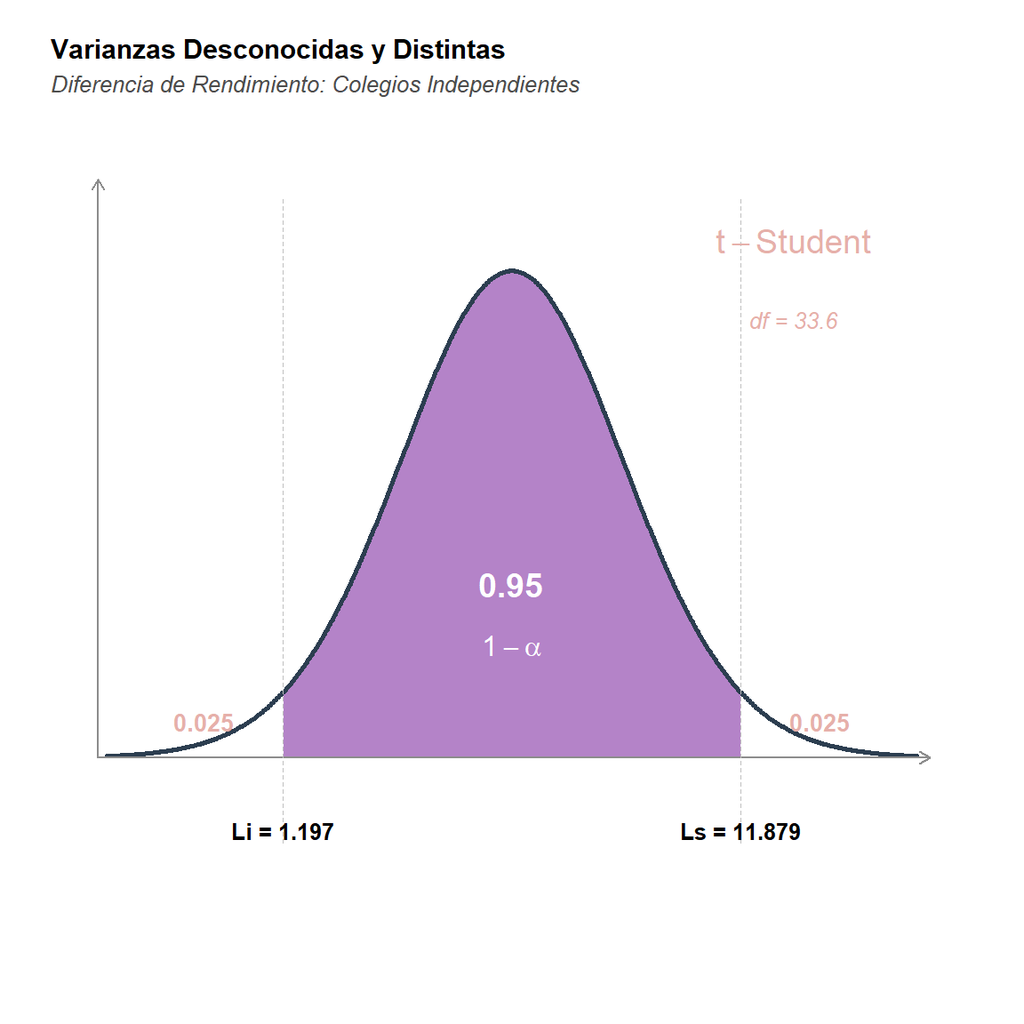

```r
color_linea     <- "#2C3E50" # Azul pizarra oscuro para la curva y ejes
color_relleno   <- "#9B59B6" # Morado para el área central (95%)
color_lineas_v  <- "gray75"  # Gris suave para las líneas verticales
color_rosado    <- "#E6B0AA" # Rosado pastel para los valores de las colas y títulos
# =====================================================================

# 1. Datos del ejercicio extraídos de la imagen
dif_medias <- 6.538
gl         <- 33.624  # Grados de libertad (Welch)
li         <- 1.197
ls         <- 11.879
confianza  <- 0.95
cola       <- 0.025

# 2. Rango y densidad de la distribución t-Student escalada a los datos
ee         <- 5.341 / 2.033 # Error estándar aproximado
x_min      <- dif_medias - 3.6 * ee
x_max      <- dif_medias + 3.6 * ee
x          <- seq(x_min, x_max, length.out = 600)
y          <- dt((x - dif_medias) / ee, df = gl) / ee
y_max      <- max(y) * 1.25

# 3. Lienzo en blanco con espacio arriba para el título de dos líneas
par(mar = c(3, 1.5, 3.5, 1.5))
plot(x, y, type = "n",
     xlim = c(x_min - 0.5, x_max + 0.5),
     ylim = c(-y_max * 0.22, y_max),
     axes = FALSE, xlab = "", ylab = "")

# Títulos superiores (Título principal y subtítulo del problema)
title(main = "Varianzas Desconocidas y Distintas",
      cex.main = 0.95, font.main = 2, line = 1.8, adj = 0)
mtext("Diferencia de Rendimiento: Colegios Independientes",
      side = 3, line = 0.6, cex = 0.8, font = 3, adj = 0, col = "gray30")

# 4. Sombreado del área central (1 - alpha)
zona <- x >= li & x <= ls
polygon(c(li, x[zona], ls),
        c(0, y[zona], 0),
        col = adjustcolor(color_relleno, alpha.f = 0.75),
        border = NA)

# 5. Curva t-Student encima del sombreado
lines(x, y, col = color_linea, lwd = 2.5)

# 6. Ejes con flechas
arrows(x_min - 0.2, 0, x_max + 0.3, 0, length = 0.07, col = "gray55", lwd = 1) # Eje X
arrows(x_min - 0.2, 0, x_min - 0.2, y_max * 0.95, length = 0.07, col = "gray55", lwd = 1) # Eje Y

# 7. Líneas verticales sutiles en los límites críticos
segments(x0 = c(li, ls), y0 = -y_max * 0.14,
         x1 = c(li, ls), y1 = y_max * 0.92,
         col = color_lineas_v, lwd = 0.8, lty = 2)

# 8. Etiquetas de límites inferiores y superiores (Li y Ls numéricos)
text(x = li, y = -y_max * 0.08,
     labels = paste0("Li = ", li),
     pos = 1, font = 2, cex = 0.8)

text(x = ls, y = -y_max * 0.08,
     labels = paste0("Ls = ", ls),
     pos = 1, font = 2, cex = 0.8)

# 9. Textos interiores centrados en el área sombreada (0.95 y 1 - alpha)
x_centro <- sum(x[zona] * y[zona]) / sum(y[zona])
y_centro <- mean(y[zona]) * 0.52

text(x = x_centro, y = y_centro + y_max * 0.04,
     labels = confianza, font = 2, cex = 1.15, col = "white")

text(x = x_centro, y = y_centro - y_max * 0.06,
     labels = expression(1 - alpha), cex = 1, col = "white")

# 10. Valores de probabilidad en ambas colas (en rosado pastel)
text(x = li - (li - x_min) * 0.45, y = y_max * 0.06,
     labels = cola, cex = 0.85, font = 2, col = color_rosado)

text(x = ls + (x_max - ls) * 0.45, y = y_max * 0.06,
     labels = cola, cex = 0.85, font = 2, col = color_rosado)

# 11. Etiqueta flotante de la t-Student a la derecha (en rosado pastel)
text(x = x_max * 0.82, y = y_max * 0.85,
     labels = expression(t-Student), cex = 1.2, font = 2, col = color_rosado)

text(x = x_max * 0.82, y = y_max * 0.72,
     labels = paste0("df = ", round(gl, 1)),
     font = 3, cex = 0.82, col = color_rosado)
```

**Gráfica de 100 intervalos**

**Ver código**

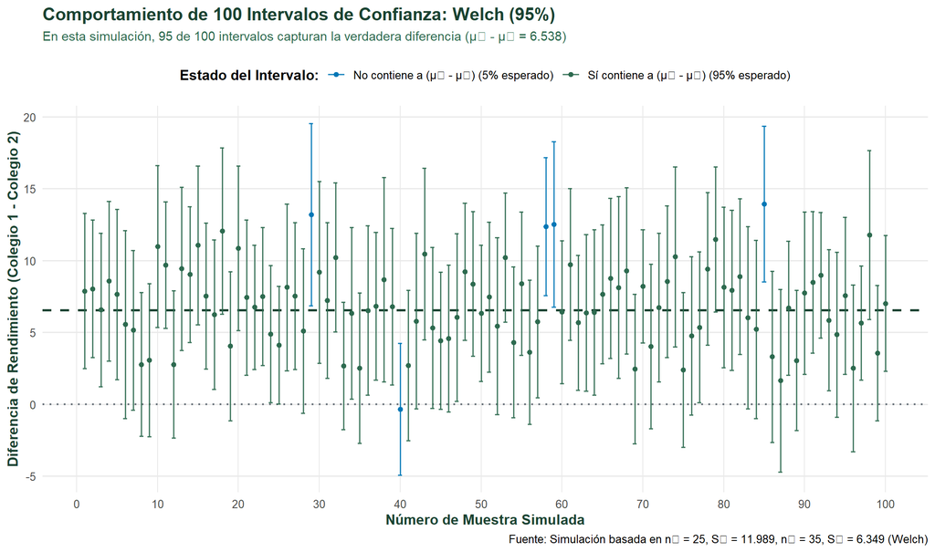

```r
library(dplyr)
library(ggplot2)

# Fijar semilla para reproducibilidad
set.seed(707)

# Parámetros exactos del ejercicio
mu1_ref <- 86.212
s1_ref <- 11.989
n1 <- 25

mu2_ref <- 79.674
s2_ref <- 6.349
n2 <- 35

diff_real <- mu1_ref - mu2_ref # 6.538
num_simulaciones <- 100

# Simulación de las 100 muestras independientes con varianzas distintas (Welch)
datos_ic <- tibble(
  muestra = 1:num_simulaciones
) %>%
  rowwise() %>%
  mutate(
    m1 = list(rnorm(n1, mean = mu1_ref, sd = s1_ref)),
    m2 = list(rnorm(n2, mean = mu2_ref, sd = s2_ref)),
    x1_sim = mean(m1),
    x2_sim = mean(m2),
    s1_sim = sd(m1),
    s2_sim = sd(m2),
    diff_muestral = x1_sim - x2_sim,
    # Error estándar de Welch
    ee_welch = sqrt((s1_sim^2 / n1) + (s2_sim^2 / n2)),
    # Grados de libertad de Welch (Satterthwaite) por muestra simulada
    nu_welch = ((s1_sim^2 / n1 + s2_sim^2 / n2)^2) /
               (((s1_sim^2 / n1)^2 / (n1 - 1)) + ((s2_sim^2 / n2)^2 / (n2 - 1))),
    t_critico = qt(0.975, df = nu_welch),
    margen_error = t_critico * ee_welch,
    lim_inf = diff_muestral - margen_error,
    lim_sup = diff_muestral + margen_error,
    contiene_diff = ifelse(lim_inf <= diff_real & lim_sup >= diff_real,
                           "Sí contiene a (μ₁ - μ₂) (95% esperado)",
                           "No contiene a (μ₁ - μ₂) (5% esperado)")
  ) %>%
  ungroup()

# Conteo exacto de aciertos
total_aciertos <- sum(datos_ic$lim_inf <= diff_real & datos_ic$lim_sup >= diff_real)

# Creación del gráfico con tonos verdes y azules
ggplot(datos_ic, aes(x = muestra, y = diff_muestral, color = contiene_diff)) +
  # Línea de referencia en 0 (indica igualdad de rendimiento)
  geom_hline(yintercept = 0, linetype = "dotted", color = "#6C757D", linewidth = 0.8) +
  # Línea horizontal de referencia para la diferencia real (6.538)
  geom_hline(yintercept = diff_real, linetype = "dashed", color = "#1B4332", linewidth = 0.9) +
  # Barras de los intervalos de confianza
  geom_errorbar(aes(ymin = lim_inf, ymax = lim_sup), width = 0.5, linewidth = 0.65, alpha = 0.85) +
  # Puntos centrales (diferencias muestrales)
  geom_point(size = 1.6) +
  # Paleta de colores: Verde Esmeralda y Azul Intenso
  scale_color_manual(
    values = c(
      "Sí contiene a (μ₁ - μ₂) (95% esperado)" = "#2D6A4F", # Verde esmeralda bosque
      "No contiene a (μ₁ - μ₂) (5% esperado)" = "#0077B6"  # Azul zafiro / brillante
    )
  ) +
  scale_x_continuous(breaks = seq(0, 100, by = 10)) +
  labs(
    title = "Comportamiento de 100 Intervalos de Confianza: Welch (95%)",
    subtitle = paste0("En esta simulación, ", total_aciertos, " de 100 intervalos capturan la verdadera diferencia (μ₁ - μ₂ = 6.538)"),
    x = "Número de Muestra Simulada",
    y = "Diferencia de Rendimiento (Colegio 1 - Colegio 2)",
    color = "Estado del Intervalo:",
    caption = "Fuente: Simulación basada en n₁ = 25, S₁ = 11.989, n₂ = 35, S₂ = 6.349 (Welch)"
  ) +
  theme_minimal(base_size = 12) +
  theme(
    plot.title = element_text(face = "bold", size = 15, color = "#1B4332"),
    plot.subtitle = element_text(size = 11, color = "#2D6A4F", margin = margin(b = 12)),
    legend.position = "top",
    legend.title = element_text(face = "bold"),
    panel.grid.minor = element_blank(),
    panel.grid.major.x = element_line(color = "#EAEAEA", linewidth = 0.4),
    axis.title = element_text(face = "bold", color = "#1B4332")
  )
```

**Interpretación** Si se construyen 100 intervalos de confianza, se espera que 95 de esos intervalos van a tener la verdadera diferencia de rendimiento entre los dos colegios ($\mu_1 - \mu_2 = 6.538$ puntos) y 5 no.

**NotaEjemplo 8. Diferencia de proporciones**

**Situación.** Se comparan las proporciones de estudiantes que entregan puntualmente sus proyectos en dos colegios. Se seleccionan muestras independientes de 120 estudiantes del colegio A y 100 del colegio B.

**Fórmula:**

$$IC_{p_1-p_2}=
(\widehat{p}_1-\widehat{p}_2)
\pm z_{1-\alpha/2}
\sqrt{
\frac{\widehat{p}_1(1-\widehat{p}_1)}{n_1}
+
\frac{\widehat{p}_2(1-\widehat{p}_2)}{n_2}
}$$

**Procedimiento y sustitución:**

**Ver código**

```r
set.seed(808)

n1 <- 120
n2 <- 100

A <- rbinom(n1, 1, 0.70)
B <- rbinom(n2, 1, 0.60)

e1 <- sum(A)
e2 <- sum(B)

p1 <- e1/n1
p2 <- e2/n2

dif <- p1-p2

se <- sqrt(p1*(1-p1)/n1+p2*(1-p2)/n2)
margen <- z*se

ic <- intervalo(dif, margen)

paso(sprintf(
  "\\widehat{p}_1=\\frac{%d}{%d}=%.3f",
  e1, n1, p1
))
```

$$\widehat{p}_1=\frac{88}{120}=0.733$$

**Ver código**

```r
paso(sprintf(
  "\\widehat{p}_2=\\frac{%d}{%d}=%.3f",
  e2, n2, p2
))
```

$$\widehat{p}_2=\frac{62}{100}=0.620$$

**Ver código**

```r
paso(sprintf(
  "IC_{95\\%%}=(%.3f-%.3f)\\pm1.960\\sqrt{\\frac{%.3f(1-%.3f)}{%d}+\\frac{%.3f(1-%.3f)}{%d}}",
  p1, p2, p1, p1, n1, p2, p2, n2
))
```

$$IC_{95\%}=(0.733-0.620)\pm1.960\sqrt{\frac{0.733(1-0.733)}{120}+\frac{0.620(1-0.620)}{100}}$$

**Ver código**

```r
paso(sprintf(
  "IC_{95\\%%}=%.3f\\pm%.3f",
  dif, margen
))
```

$$IC_{95\%}=0.113\pm0.124$$

**Ver código**

```r
paso(sprintf(
  "\\boxed{IC_{95\\%%}=[%.2f\\%%,\\ %.2f\\%%]}",
  100*ic[1], 100*ic[2]
))
```

$$\boxed{IC_{95\%}=[-1.04\%,\ 23.71\%]}$$

**Gráfica**

**Ver código**

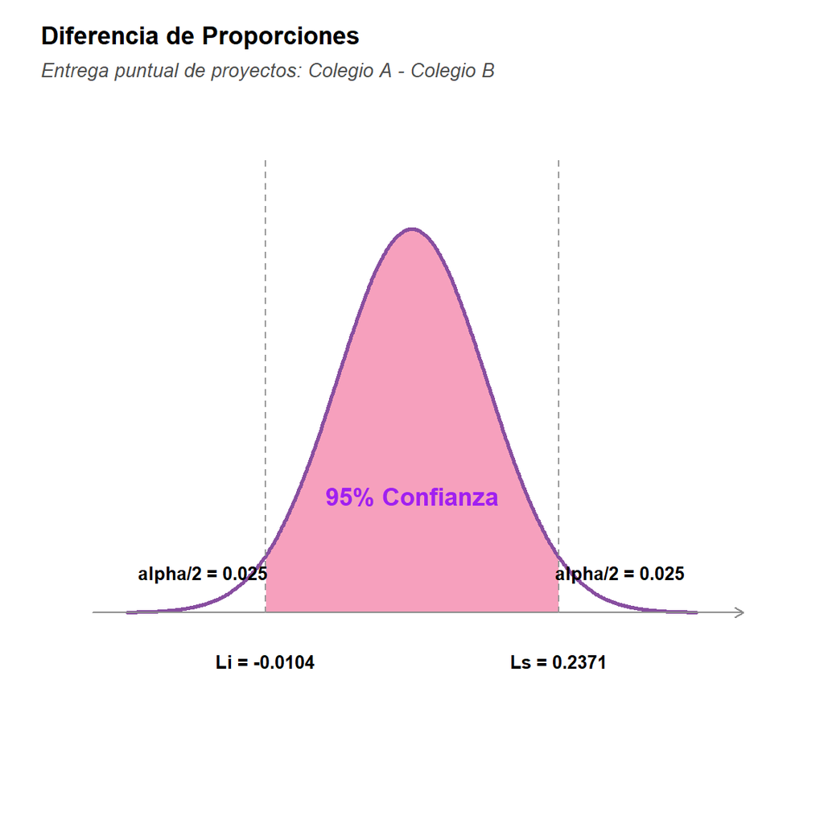

```r
color_linea     <- "#884EA0" # Tono fucsia/morado oscuro para la curva y ejes
color_relleno   <- "#F48FB1" # Rosado pastel/fucsia para el área central (95%)
color_lineas_v  <- "gray60"  # Gris para las líneas verticales punteadas
color_texto     <- "purple" # Verde oscuro para la etiqueta de confianza (estilo referencia)
# =====================================================================

# 1. Datos del ejercicio (Diferencia de proporciones)
# p1 = 88/120 = 0.733, p2 = 62/100 = 0.620[cite: 12]
dif_proporciones <- 0.733 - 0.620                # 0.113
ee               <- sqrt((0.733 * (1 - 0.733) / 120) + (0.620 * (1 - 0.620) / 100)) # Error estándar
li               <- -0.0104                        # Límite inferior (-1.04%)[cite: 12]
ls               <- 0.2371                         # Límite superior (23.71%)[cite: 12]
confianza_txt    <- "95% Confianza"
cola_txt         <- "alpha/2 = 0.025"

# 2. Rango y densidad de la distribución Normal
x_min <- dif_proporciones - 3.8 * ee
x_max <- dif_proporciones + 3.8 * ee
x     <- seq(x_min, x_max, length.out = 600)
y     <- dnorm(x, mean = dif_proporciones, sd = ee)
y_max <- max(y) * 1.25

# 3. Lienzo en blanco con espacio arriba para los títulos de dos líneas
par(mar = c(3, 1.5, 4.0, 1.5))
plot(x, y, type = "n",
     xlim = c(x_min - 0.05, x_max + 0.05),
     ylim = c(-y_max * 0.22, y_max),
     axes = FALSE, xlab = "", ylab = "")

# Títulos superiores idénticos al estilo de la referencia
title(main = "Diferencia de Proporciones",
      cex.main = 1.1, font.main = 2, line = 2.4, adj = 0)
mtext("Entrega puntual de proyectos: Colegio A - Colegio B",
      side = 3, line = 1.0, cex = 0.85, font = 3, adj = 0, col = "gray30")

# 4. Sombreado del área central (intervalo de confianza)
zona <- x >= li & x <= ls
polygon(c(li, x[zona], ls),
        c(0, y[zona], 0),
        col = adjustcolor(color_relleno, alpha.f = 0.85),
        border = NA)

# 5. Curva Normal encima del sombreado
lines(x, y, col = color_linea, lwd = 2.5)

# 6. Eje horizontal inferior con flecha
arrows(x_min - 0.03, 0, x_max + 0.04, 0, length = 0.07, col = "gray55", lwd = 1)

# 7. Líneas verticales punteadas en los límites de confianza (Li y Ls)
segments(x0 = c(li, ls), y0 = 0,
         x1 = c(li, ls), y1 = y_max * 0.95,
         col = color_lineas_v, lwd = 1, lty = 2)

# 8. Etiquetas de los límites inferiores y superiores en el eje X
text(x = li, y = -y_max * 0.06,
     labels = paste0("Li = ", li),
     pos = 1, font = 2, cex = 0.8)

text(x = ls, y = -y_max * 0.06,
     labels = paste0("Ls = ", ls),
     pos = 1, font = 2, cex = 0.8)

# 9. Texto central de confianza dentro del área sombreada
x_centro <- sum(x[zona] * y[zona]) / sum(y[zona])
y_centro <- mean(y[zona]) * 0.50

text(x = x_centro, y = y_centro,
     labels = confianza_txt, font = 2, cex = 1.1, col = color_texto)

# 10. Valores de probabilidad en ambas colas (alpha/2 = 0.025)
text(x = li - (li - x_min) * 0.45, y = y_max * 0.08,
     labels = cola_txt, cex = 0.8, font = 2, col = "black")

text(x = ls + (x_max - ls) * 0.45, y = y_max * 0.08,
     labels = cola_txt, cex = 0.8, font = 2, col = "black")
```

**Interpretación.** El intervalo del 95 % estima la diferencia entre las proporciones poblacionales de estudiantes que entregan puntualmente sus proyectos. Sus extremos se expresan en puntos porcentuales.

Si el intervalo contiene cero, no se descarta la igualdad de proporciones poblacionales al nivel bilateral del 5 %.

**Gráfica de 100 intervalos**

**Ver código**

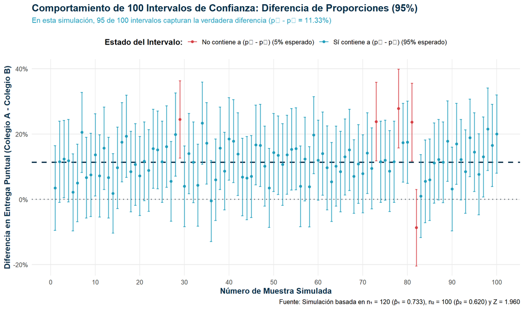

```r
library(dplyr)
library(ggplot2)

# Fijar semilla para reproducibilidad
set.seed(808)

# Parámetros exactos del ejercicio
p1_ref <- 88 / 120 # 0.7333333
n1 <- 120

p2_ref <- 62 / 100 # 0.620
n2 <- 100

diff_real <- p1_ref - p2_ref # 0.1133333 (~11.33%)
z_critico <- qnorm(0.975)    # 1.959964 (~1.960)
num_simulaciones <- 100

# Simulación de las 100 pares de muestras binomiales independientes
datos_ic <- tibble(
  muestra = 1:num_simulaciones,
  x1_sim = rbinom(num_simulaciones, size = n1, prob = p1_ref),
  x2_sim = rbinom(num_simulaciones, size = n2, prob = p2_ref),
  p1_sim = x1_sim / n1,
  p2_sim = x2_sim / n2
) %>%
  mutate(
    diff_muestral = p1_sim - p2_sim,
    error_estandar = sqrt((p1_sim * (1 - p1_sim) / n1) + (p2_sim * (1 - p2_sim) / n2)),
    margen_error = z_critico * error_estandar,
    lim_inf = diff_muestral - margen_error,
    lim_sup = diff_muestral + margen_error,
    contiene_diff = ifelse(lim_inf <= diff_real & lim_sup >= diff_real,
                           "Sí contiene a (p₁ - p₂) (95% esperado)",
                           "No contiene a (p₁ - p₂) (5% esperado)")
  )

# Conteo exacto de aciertos
total_aciertos <- sum(datos_ic$lim_inf <= diff_real & datos_ic$lim_sup >= diff_real)

# Creación del gráfico con nueva paleta de colores (Azul Petróleo vs Terracota/Coral)
ggplot(datos_ic, aes(x = muestra, y = diff_muestral, color = contiene_diff)) +
  # Línea de referencia en 0% (indica igualdad de proporciones entre colegios)
  geom_hline(yintercept = 0, linetype = "dotted", color = "#6C757D", linewidth = 0.8) +
  # Línea horizontal de referencia para la diferencia real (11.33%)
  geom_hline(yintercept = diff_real, linetype = "dashed", color = "#003049", linewidth = 0.9) +
  # Barras de los intervalos de confianza
  geom_errorbar(aes(ymin = lim_inf, ymax = lim_sup), width = 0.5, linewidth = 0.65, alpha = 0.85) +
  # Puntos centrales (diferencias de proporciones muestrales)
  geom_point(size = 1.6) +
  # Paleta de colores renovada
  scale_color_manual(
    values = c(
      "Sí contiene a (p₁ - p₂) (95% esperado)" = "#219EBC", # Azul petróleo / cian profundo
      "No contiene a (p₁ - p₂) (5% esperado)" = "#D64045"  # Terracota / rojo coral
    )
  ) +
  scale_y_continuous(labels = scales::percent_format(accuracy = 1)) +
  scale_x_continuous(breaks = seq(0, 100, by = 10)) +
  labs(
    title = "Comportamiento de 100 Intervalos de Confianza: Diferencia de Proporciones (95%)",
    subtitle = paste0("En esta simulación, ", total_aciertos, " de 100 intervalos capturan la verdadera diferencia (p₁ - p₂ = 11.33%)"),
    x = "Número de Muestra Simulada",
    y = "Diferencia en Entrega Puntual (Colegio A - Colegio B)",
    color = "Estado del Intervalo:",
    caption = "Fuente: Simulación basada en n₁ = 120 (p̂₁ = 0.733), n₂ = 100 (p̂₂ = 0.620) y Z = 1.960"
  ) +
  theme_minimal(base_size = 12) +
  theme(
    plot.title = element_text(face = "bold", size = 15, color = "#003049"),
    plot.subtitle = element_text(size = 11, color = "#219EBC", margin = margin(b = 12)),
    legend.position = "top",
    legend.title = element_text(face = "bold"),
    panel.grid.minor = element_blank(),
    panel.grid.major.x = element_line(color = "#EAEAEA", linewidth = 0.4),
    axis.title = element_text(face = "bold", color = "#003049")
  )
```

**Interpretación** Si se construyen 100 intervalos de confianza, se espera que 95 de esos intervalos van a tener la verdadera diferencia de proporciones de estudiantes que entregan puntualmente sus proyectos entre los dos colegios ($p_1 - p_2 = 0.113$ o $11.33\%$) y 5 no.

## 2.2 Conclusiones

La estimación puntual ofrece un valor representativo de un parámetro, mientras que los intervalos de confianza comunican la incertidumbre del muestreo. La elección correcta de la fórmula depende de **qué parámetro** se estima, de **cuántas poblaciones** se comparan, de la **independencia o apareamiento**, del conocimiento de las varianzas y de los **supuestos distribucionales**. En educación, estas herramientas permiten estudiar promedios, proporciones y variabilidad de resultados sin confundir diferencias estadísticas con efectos causales.